# Machine Learning Project

Iván Torresano Villafranca

2024-04-24

## Introduction

This dataset was downloaded from kaggle: https://www.kaggle.com/datasets/uciml/adult-census-income and the source is a 1994 Census bureau database by Ronny Kohavi and Barry Becker (Data Mining and Visualization, Silicon Graphics). The prediction task of this dataset is to determine whether a person makes over 50.000$\$$ a year. Developing an algorithm to predict whether a person will earn more than 50.000$\$$ per year can be useful in several fields such as human resources, to determine if a candidate has the potential to reach a good salary, market segmentation for customizing their marketing and sales strategies to reach that specific segment of the population, personal financial planning, public policy and taxation, as well as economic research.

Description of the features of the dataset:

**age:** Age of each individual in years

**workclass:** Working class of the individual. Nominal categorical variable with categories: Private, Self-emp-not-inc, Self-emp-inc, Federal-gov, Local-gov, State-gov, Without-pay, Never-worked.

**fnlwgt:** Represents weighted estimates of the US civilian non institutional population, derived from the Current Population Survey (CPS) files. These weights are adjusted based on demographic characteristics such as age, sex, race, and Hispanic origin to ensure representative sampling within each state.

**education:** Level of education in ascending order. Categorical ordinal feature with the following categories: Bachelors, Some-college, 11th, HS-grad, Prof-school, Assoc-acdm, Assoc-voc, 9th, 7th-8th, 12th, Masters, 1st-4th, 10th, Doctorate, 5th-6th, Preschool.

**education.num:** The level of education of the individual codified as an integer.

**marital.status:** Indicates the marital state of the individual. Categorical nominal variable with categories: Married-civ-spouse, Divorced, Never-married, Separated, Widowed, Married-spouse-absent, Married-AF-spouse.

**occupation:** Working sector or area of the individual (categorical nominal variable)

**sex:** Gender of the person (categorical nominal variable)

**capital.gain:** Represents the financial gains obtained by the individual (numeric variable)

**capital.loss:** Represents the financial losses obtained by the individual (numeric variable)

**hours.per.week:** The weekly work hours of the individual (numeric variable)

**native.country:** Country where the person was born (categorical nominal variable)

**income:** Target variable with categories: ‘<=50K’, ‘50>=k’

```r
df <- read.csv('adult.csv')
str(df)
```

```
## 'data.frame':    32561 obs. of  15 variables:
##  $ age           : int  90 82 66 54 41 34 38 74 68 41 ...
##  $ workclass     : chr  "?" "Private" "?" "Private" ...
##  $ fnlwgt        : int  77053 132870 186061 140359 264663 216864 150601 88638 422013 70037 ...
##  $ education     : chr  "HS-grad" "HS-grad" "Some-college" "7th-8th" ...
##  $ education.num : int  9 9 10 4 10 9 6 16 9 10 ...
##  $ marital.status: chr  "Widowed" "Widowed" "Widowed" "Divorced" ...
##  $ occupation    : chr  "?" "Exec-managerial" "?" "Machine-op-inspct" ...
##  $ relationship  : chr  "Not-in-family" "Not-in-family" "Unmarried" "Unmarried" ...
##  $ race          : chr  "White" "White" "Black" "White" ...
##  $ sex           : chr  "Female" "Female" "Female" "Female" ...
##  $ capital.gain  : int  0 0 0 0 0 0 0 0 0 0 ...
##  $ capital.loss  : int  4356 4356 4356 3900 3900 3770 3770 3683 3683 3004 ...
##  $ hours.per.week: int  40 18 40 40 40 45 40 20 40 60 ...
##  $ native.country: chr  "United-States" "United-States" "United-States" "United-States" ...
##  $ income        : chr  "<=50K" "<=50K" "<=50K" "<=50K" ...
```

```r
summary(df)
```

```
##       age         workclass             fnlwgt         education
##  Min.   :17.00   Length:32561       Min.   :  12285   Length:32561
##  1st Qu.:28.00   Class :character   1st Qu.: 117827   Class :character
##  Median :37.00   Mode  :character   Median : 178356   Mode  :character
##  Mean   :38.58                      Mean   : 189778
##  3rd Qu.:48.00                      3rd Qu.: 237051
##  Max.   :90.00                      Max.   :1484705
##  education.num   marital.status      occupation        relationship
##  Min.   : 1.00   Length:32561       Length:32561       Length:32561
##  1st Qu.: 9.00   Class :character   Class :character   Class :character
##  Median :10.00   Mode  :character   Mode  :character   Mode  :character
##  Mean   :10.08
##  3rd Qu.:12.00
##  Max.   :16.00
##      race               sex             capital.gain    capital.loss
##  Length:32561       Length:32561       Min.   :    0   Min.   :   0.0
##  Class :character   Class :character   1st Qu.:    0   1st Qu.:   0.0
##  Mode  :character   Mode  :character   Median :    0   Median :   0.0
##                                        Mean   : 1078   Mean   :  87.3
##                                        3rd Qu.:    0   3rd Qu.:   0.0
##                                        Max.   :99999   Max.   :4356.0
##  hours.per.week  native.country        income
##  Min.   : 1.00   Length:32561       Length:32561
##  1st Qu.:40.00   Class :character   Class :character
##  Median :40.00   Mode  :character   Mode  :character
##  Mean   :40.44
##  3rd Qu.:45.00
##  Max.   :99.00
```

The dataset consists of 32561 observations and 15 attributes. As some of the categorical variables are codified as characters, we codify them as factors, including the target variable. Before codifying the variables, it is important to realize that features: “occupation”,“workclass” and “native.country” have ‘?’ values, so we replace them by NA:

```r
#Change ? by NAS
df$workclass[df$workclass == '?'] = NA
df$occupation[df$occupation == '?'] = NA
df$native.country[df$native.country == '?'] = NA
#Codify the variables as factors
df$workclass <- factor(df$workclass)
df$education <- factor(df$education)
df$marital.status <- factor(df$marital.status)
df$occupation <- factor(df$occupation)
df$relationship <- factor(df$relationship)
df$sex <- factor(df$sex)
df$income <- factor(df$income)
df$race <- factor(df$race)
df$native.country <- factor(df$native.country)
```

In the dataset, there are 2 features called ‘education’ and ‘education.num’, which represent the same information but encoded in a different way. We will keep “education.num”, but encoded as a factor, since it this variable can take only 16 different values.

```r
df <- df %>% select(-education)
df$education.num <- factor(df$education.num)
str(df)
```

```
## 'data.frame':    32561 obs. of  14 variables:
##  $ age           : int  90 82 66 54 41 34 38 74 68 41 ...
##  $ workclass     : Factor w/ 8 levels "Federal-gov",..: NA 4 NA 4 4 4 4 7 1 4 ...
##  $ fnlwgt        : int  77053 132870 186061 140359 264663 216864 150601 88638 422013 70037 ...
##  $ education.num : Factor w/ 16 levels "1","2","3","4",..: 9 9 10 4 10 9 6 16 9 10 ...
##  $ marital.status: Factor w/ 7 levels "Divorced","Married-AF-spouse",..: 7 7 7 1 6 1 6 5 1 5 ...
##  $ occupation    : Factor w/ 14 levels "Adm-clerical",..: NA 4 NA 7 10 8 1 10 10 3 ...
##  $ relationship  : Factor w/ 6 levels "Husband","Not-in-family",..: 2 2 5 5 4 5 5 3 2 5 ...
##  $ race          : Factor w/ 5 levels "Amer-Indian-Eskimo",..: 5 5 3 5 5 5 5 5 5 5 ...
##  $ sex           : Factor w/ 2 levels "Female","Male": 1 1 1 1 1 1 2 1 1 2 ...
##  $ capital.gain  : int  0 0 0 0 0 0 0 0 0 0 ...
##  $ capital.loss  : int  4356 4356 4356 3900 3900 3770 3770 3683 3683 3004 ...
##  $ hours.per.week: int  40 18 40 40 40 45 40 20 40 60 ...
##  $ native.country: Factor w/ 41 levels "Cambodia","Canada",..: 39 39 39 39 39 39 39 39 39 NA ...
##  $ income        : Factor w/ 2 levels "<=50K",">50K": 1 1 1 1 1 1 1 2 1 2 ...
```

## EDA and preprocessing

In order to build ML algorithms, the dataset is split into train and test. As the dataset is relatively big, 70% of the data is allocated as training and the 30% left is allocated as test.

```r
train_index <- createDataPartition(df$income, p = 0.7, list = FALSE)
train <- df[train_index, ]
test <- df[-train_index,]
```

```r
#Nas in workclass and occupation
nas_per_columns <- colSums(is.na(df))
cat('Proportion of NA in workclass:', nas_per_columns['workclass']/dim(df)[1])
```

```
## Proportion of NA in workclass: 0.05638647
```

```r
cat('Proportion of NA in occupation:', nas_per_columns['occupation']/dim(df)[1])
```

```
## Proportion of NA in occupation: 0.05660146
```

```r
cat('Proportion of NA in native.country:', nas_per_columns['native.country']/dim(df)[1])
```

```
## Proportion of NA in native.country: 0.01790486
```

The proportion of NA in “workclass” and “occupation” is around 6% so we cannot simply delete them and in “native.country”, the proportion is 1.7%. To try to understand the nature of NA, we display a summary of the rows which contain missing values.

```r
summary(df[!complete.cases(df),])
```

```
##       age                   workclass        fnlwgt       education.num
##  Min.   :17.00   Private         : 410   Min.   : 12285   9      :661
##  1st Qu.:22.00   Self-emp-inc    :  42   1st Qu.:121804   10     :613
##  Median :36.00   Self-emp-not-inc:  42   Median :177906   13     :311
##  Mean   :40.39   Local-gov       :  26   Mean   :189584   7      :127
##  3rd Qu.:58.00   State-gov       :  19   3rd Qu.:232669   6      :113
##  Max.   :90.00   (Other)         :  24   Max.   :981628   14     : 96
##                  NA's            :1836                    (Other):478
##                marital.status           occupation           relationship
##  Divorced             :229    Prof-specialty : 102   Husband       :730
##  Married-AF-spouse    :  2    Other-service  :  83   Not-in-family :579
##  Married-civ-spouse   :911    Exec-managerial:  74   Other-relative: 92
##  Married-spouse-absent: 48    Craft-repair   :  69   Own-child     :602
##  Never-married        :957    Sales          :  66   Unmarried     :234
##  Separated            : 86    (Other)        : 162   Wife          :162
##  Widowed              :166    NA's           :1843
##                  race          sex        capital.gain      capital.loss
##  Amer-Indian-Eskimo:  25   Female: 989   Min.   :    0.0   Min.   :   0.00
##  Asian-Pac-Islander: 144   Male  :1410   1st Qu.:    0.0   1st Qu.:   0.00
##  Black             : 307                 Median :    0.0   Median :   0.00
##  Other             :  40                 Mean   :  897.1   Mean   :  73.87
##  White             :1883                 3rd Qu.:    0.0   3rd Qu.:   0.00
##                                          Max.   :99999.0   Max.   :4356.00
##
##  hours.per.week        native.country   income
##  Min.   : 1.00   United-States:1666   <=50K:2066
##  1st Qu.:25.00   Mexico       :  33   >50K : 333
##  Median :40.00   Canada       :  14
##  Mean   :34.23   Philippines  :  10
##  3rd Qu.:40.00   Germany      :   9
##  Max.   :99.00   (Other)      :  84
##                  NA's         : 583
```

```r
library(mice)
train_imputed <- mice(train, m=1,method = "rf" )
train <- complete(train_imputed, 1)

source("https://raw.githubusercontent.com/prockenschaub/Misc/master/R/mice.reuse/mice.reuse.R")
test_imputed <- mice.reuse(train_imputed, test)[[1]]
```

Now, we check that there are no missing values left

```r
sapply(train, function(x) sum(is.na(x)))
```

```
##            age      workclass         fnlwgt  education.num marital.status
##              0              0              0              0              0
##     occupation   relationship           race            sex   capital.gain
##              0              0              0              0              0
##   capital.loss hours.per.week native.country         income
##              0              0              0              0
```

```r
sapply(test_imputed, function(x) sum(is.na(x)))
```

```
##            age      workclass         fnlwgt  education.num marital.status
##              0              0              0              0              0
##     occupation   relationship           race            sex   capital.gain
##              0              0              0              0              0
##   capital.loss hours.per.week native.country         income
##              0              0              0              0
```

In the preprocessing part, we start analyzing some of the categorical features of the dataset such as “native.country” which have many different categories.

#### Native country

```r
cat('There are',length(unique(train$native.country)), ' countries in total')
```

```
## There are 40  countries in total
```

```r
#Observations for each country
obs_per_country <- table(train$native.country)
sort(obs_per_country, decreasing = TRUE)
```

```
##
##              United-States                     Mexico
##                      20743                        465
##                Philippines                     Canada
##                        146                         92
##                    Germany                El-Salvador
##                         92                         82
##                Puerto-Rico                       Cuba
##                         75                         73
##                      India                      China
##                         70                         65
##                    Jamaica                    England
##                         65                         64
##                      South                    Vietnam
##                         63                         53
##                      Italy         Dominican-Republic
##                         51                         47
##                   Columbia                  Guatemala
##                         45                         45
##                      Japan                     Poland
##                         45                         43
##                     Taiwan                      Haiti
##                         35                         30
##                       Iran                   Portugal
##                         30                         29
##                       Peru                     France
##                         25                         24
##                     Greece                   Cambodia
##                         21                         20
##                  Nicaragua                    Ecuador
##                         19                         17
##                       Hong                    Ireland
##                         15                         15
##                   Thailand            Trinadad&Tobago
##                         14                         13
##                 Yugoslavia                    Hungary
##                         12                         11
## Outlying-US(Guam-USVI-etc)                   Honduras
##                         11                         10
##                       Laos                   Scotland
##                          9                          9
##         Holand-Netherlands
##                          0
```

The number of different countries is very big and there are some of them with very few observations so it is a good idea to group them based on demographical, cultural and economic aspects. An example of a possible classification is the following:

**North America:** United-States, Canada

**Western Europe:**Greece, England, Germany, Italy, Ireland, France, Portugal, Scotland

**Eastern Europe:**Poland, Hungary, Yugoslavia

**Asia:** Vietnam, China, Taiwan, Philippines, India, South, Hong, Iran, Cambodia, Japan, Laos, Thailand

```r
train$region <- case_when(
  train$native.country %in% c("United-States", "Canada") ~ "North America",
  train$native.country %in% c("Greece", "England", "Germany", "Italy", "Ireland", "France", "Portugal", "Scotland","Holand-Netherlands") ~ "Western Europe",
  train$native.country %in% c("Poland", "Hungary", "Yugoslavia") ~ "Eastern Europe",
  train$native.country %in% c("Vietnam", "China", "Taiwan", "Philippines", "India", "South", "Hong", "Iran", "Cambodia", "Japan", "Laos", "Thailand") ~ "Asia",
  train$native.country %in% c("Cuba", "Trinadad&Tobago", "Mexico", "Honduras", "Puerto-Rico", "Peru", "Nicaragua", "Dominican-Republic", "El-Salvador", "Columbia", "Haiti", "Jamaica", "Guatemala", "Ecuador", "Outlying-US(Guam-USVI-etc)") ~ "Central and South America",
  TRUE ~ "Unknown"
)


test_imputed$region <- case_when(
  test_imputed$native.country %in% c("United-States", "Canada") ~ "North America",
  test_imputed$native.country %in% c("Greece", "England", "Germany", "Italy", "Ireland", "France", "Portugal", "Scotland","Holand-Netherlands") ~ "Western Europe",
  test_imputed$native.country %in% c("Poland", "Hungary", "Yugoslavia") ~ "Eastern Europe",
  test_imputed$native.country %in% c("Vietnam", "China", "Taiwan", "Philippines", "India", "South", "Hong", "Iran", "Cambodia", "Japan", "Laos", "Thailand") ~ "Asia",
  test_imputed$native.country %in% c("Cuba", "Trinadad&Tobago", "Mexico", "Honduras", "Puerto-Rico", "Peru", "Nicaragua", "Dominican-Republic", "El-Salvador", "Columbia", "Haiti", "Jamaica", "Guatemala", "Ecuador", "Outlying-US(Guam-USVI-etc)") ~ "Central and South America",
  TRUE ~ "Unknown"
)

#Delete naive.country feature from the dataset
train <- train %>% select(-native.country)
test_imputed <- test_imputed %>% select(-native.country)

#Transform region variable into a factor
train$region <- factor(train$region)
test_imputed$region <- factor(test_imputed$region)
```

Now, we show a barplot with the proportion of people with incomes greater than 50.000$\$$ in each region:

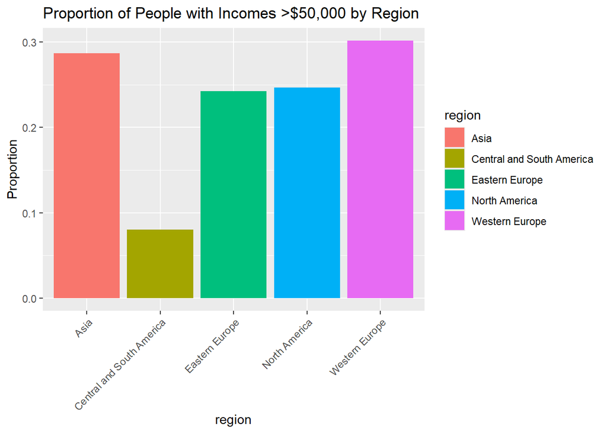

```r
#compute the proportions
proportions <- train %>%
  group_by(region) %>%
  summarise(proportion = sum(income == ">50K") / n())

#barplot of the proportion in each region
ggplot(proportions, aes(x = region, y = proportion, fill = region)) +
  geom_bar(stat = "identity") +
  labs(title = "Proportion of People with Incomes >$50,000 by Region",
       y = "Proportion") +
  theme(axis.text.x = element_text(angle = 45, hjust = 1))  # Rotate x-axis labels for better readability
```

There are some significant differences in the proportion of “wealth” people across the regions. For instance, Central and South America is by far the region with the smallest proportion, so if there is an individual in the test that belongs to Central-South America, it is very likely that he or she earns less than 50.000$\$$ a year.

#### Race

This attribute indicates the race of the individuals of the dataset. In the summary showed at the beginning of the document, is observed that the categories are highly imbalanced and most of the individuals belong to “white” race.

```r
#Observations that correspond to each race in the dataset
table(train$race)
```

```
##
## Amer-Indian-Eskimo Asian-Pac-Islander              Black              Other
##                217                746               2168                184
##              White
##              19478
```

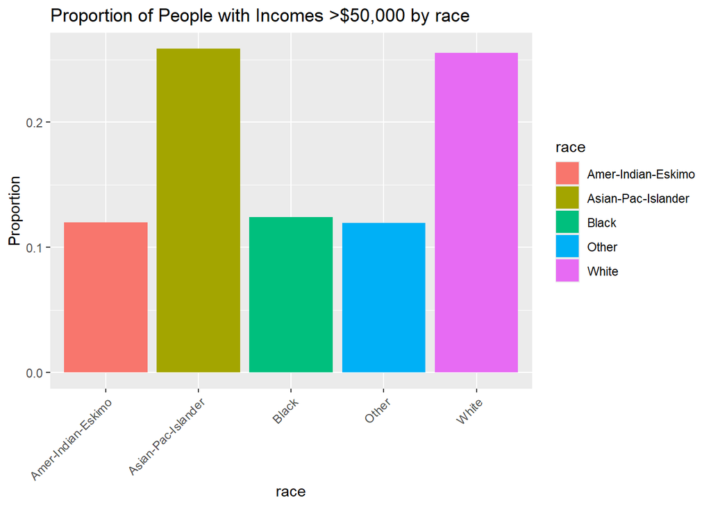

```r
#compute the proportions
proportions <- train %>%
  group_by(race) %>%
  summarise(proportion = sum(income == ">50K") / n())

#barplot of the proportion of "wealth" people for each race
ggplot(proportions, aes(x = race, y = proportion, fill = race)) +
  geom_bar(stat = "identity") +
  labs(title = "Proportion of People with Incomes >$50,000 by race",
       y = "Proportion") +
  theme(axis.text.x = element_text(angle = 45, hjust = 1))  # Rotate x-axis labels for better readability
```

Watching this barplot, we group all the observations in only two categories: “White-Asian” and “Others”

```r
#Rearranging race categories
train <- train %>%
  mutate(
    race = ifelse(race %in% c("White", "Asian-Pac-Islander"), "White-Asian",
                  ifelse(race %in% c("Black", "Amer-Indian-Eskimo", "Other"), "Other", race))
  )
train$race <- factor(train$race)

#Rearranging race  categories in test data
test_imputed <- test_imputed %>%
  mutate(
    race = ifelse(race %in% c("White", "Asian-Pac-Islander"), "White-Asian",
                  ifelse(race %in% c("Black", "Amer-Indian-Eskimo", "Other"), "Other", race))
  )
test_imputed$race <- factor(test_imputed$race)
```

#### Marital status

```r
table(train$marital.status)
```

```
##
##              Divorced     Married-AF-spouse    Married-civ-spouse
##                  3119                    17                 10475
## Married-spouse-absent         Never-married             Separated
##                   287                  7494                   699
##               Widowed
##                   702
```

There are some categories such as “Married-AF-spouse” with very few observations. We analyse if the proportion of “wealth” people varies significantly across the different categories.

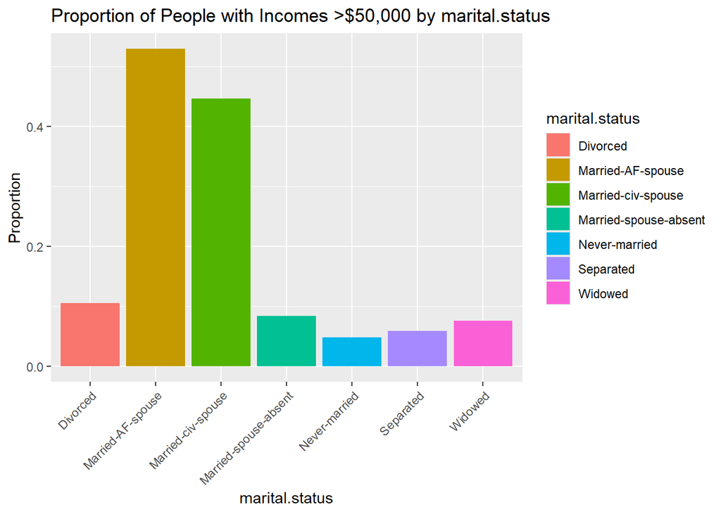

```r
proportions <- train %>%
  group_by(marital.status) %>%
  summarise(proportion = sum(income == ">50K") / n())

#barplot of the proportion of each categorie of marital.status
ggplot(proportions, aes(x = marital.status, y = proportion, fill = marital.status)) +
  geom_bar(stat = "identity") +
  labs(title = "Proportion of People with Incomes >$50,000 by marital.status",
       y = "Proportion") +
  theme(axis.text.x = element_text(angle = 45, hjust = 1))  # Rotate x-axis labels for better readability
```

According to this barplot, there is a significant distinction between individuals who are married and have a present spouse and individuals which are not married, or for whatever reason do not coexist with their spouse, so we group the observations of “marital.status” into “Spouse” and “Not spouse”.

```r
#Rearranging marital.status categories
train <- train %>%
  mutate(
    marital.status = ifelse(marital.status %in% c("Married-AF-spouse", "Married-civ-spouse"), "Spouse",
                  ifelse(marital.status %in% c("Divorced", "Separated", "Widowed","Never-married","Married-spouse-absent"), "Not spouse", marital.status))
  )
train$marital.status <- factor(train$marital.status)

test_imputed <- test_imputed %>%
  mutate(
    marital.status = ifelse(marital.status %in% c("Married-AF-spouse", "Married-civ-spouse"), "Spouse",
                  ifelse(marital.status %in% c("Divorced", "Separated", "Widowed","Never-married","Married-spouse-absent"), "Not spouse", marital.status))
  )
test_imputed$marital.status <- factor(test_imputed$marital.status)
```

#### Relationship

```r
table(train$relationship)
```

```
##
##        Husband  Not-in-family Other-relative      Own-child      Unmarried
##           9209           5819            684           3580           2391
##           Wife
##           1110
```

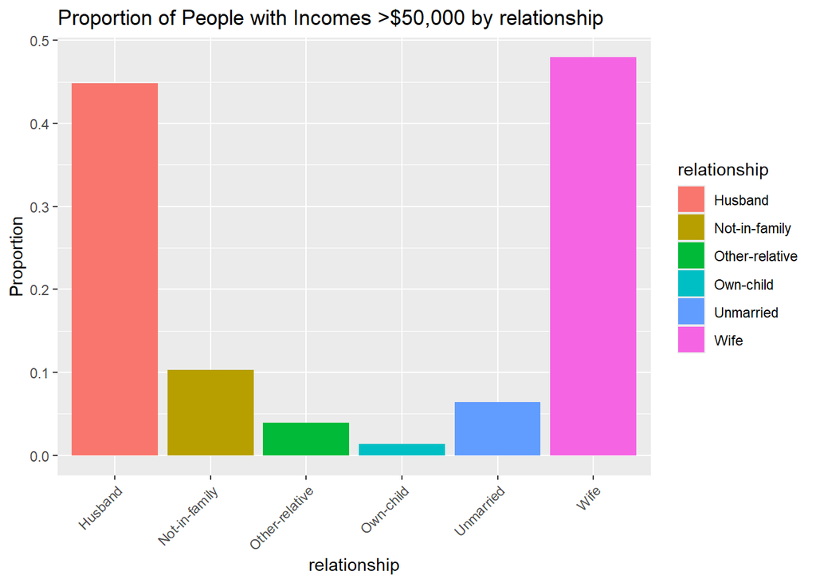

```r
proportions <- train %>%
  group_by(relationship) %>%
  summarise(proportion = sum(income == ">50K") / n())

#barplot of the proportion in each region
ggplot(proportions, aes(x = relationship, y = proportion, fill = relationship)) +
  geom_bar(stat = "identity") +
  labs(title = "Proportion of People with Incomes >$50,000 by relationship",
       y = "Proportion") +
  theme(axis.text.x = element_text(angle = 45, hjust = 1))  # Rotate x-axis labels for better readability
```

Here, as is the case with ‘marital status’, we observe a very similar trend: the highest proportion of wealthy individuals are those who are married (either as husbands or wives), while those who are unmarried tend to have the lowest proportion. However, among the unmarried individuals, there is more variability in this proportion.

```r
#We group husband and wife in the same category
train$relationship <- as.character(train$relationship)
train$relationship[train$relationship %in% c("Husband", "Wife")] <- "Spouse"
train$relationship <- factor(train$relationship)

test_imputed$relationship <- as.character(test_imputed$relationship)
test_imputed$relationship[test_imputed$relationship %in% c("Husband",
                                                           "Wife")] <- "Spouse"
test_imputed$relationship <- factor(test_imputed$relationship)
```

As the variables “marital.status” and “relationship” look similar, we carry out a $\chi^2$ test to check if there is an association between these $2$ variables.

```r
contingency_table <- table(train$marital.status, train$relationship)
print(contingency_table)
```

```
##
##              Not-in-family Other-relative Own-child Spouse Unmarried
##   Not spouse          5810            600      3500      0      2391
##   Spouse                 9             84        80  10319         0
```

```r
chisq.test(contingency_table)
```

```
##
##  Pearson's Chi-squared test
##
## data:  contingency_table
## X-squared = 22145, df = 4, p-value < 2.2e-16
```

By looking at the contingency table and from the p-value obtained in the $\chi^2$ test, there is clear evidence of association between these 2 categorical variables. As the aim of this project is to predict the output with the highest performance possible, we will keep both features in the dataset.

#### Workclass

```r
#observations corresponding to each workclass
table(train$workclass)
```

```
##
##      Federal-gov        Local-gov     Never-worked          Private
##              701             1525                6            16922
##     Self-emp-inc Self-emp-not-inc        State-gov      Without-pay
##              804             1880              946                9
```

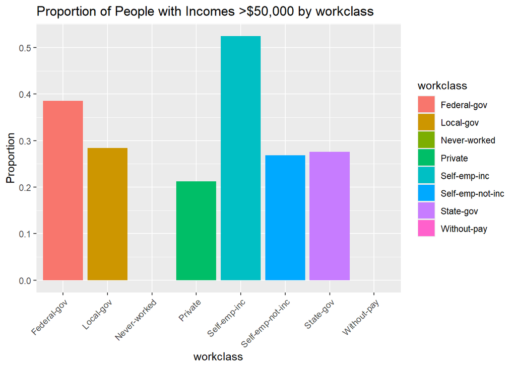

```r
proportions <- train %>%
  group_by(workclass) %>%
  summarise(proportion = sum(income == ">50K") / n())

#barplot of the proportion of wealth people for each workclass
ggplot(proportions, aes(x = workclass, y = proportion, fill = workclass)) +
  geom_bar(stat = "identity") +
  labs(title = "Proportion of People with Incomes >$50,000 by workclass",
       y = "Proportion") +
  theme(axis.text.x = element_text(angle = 45, hjust = 1))  # Rotate x-axis labels for better readability
```

In this case, we see that there are two categories: “Never-worked” and “Without-pay” in which the proportion of “wealth” individuals is 0 so we group them in one single category. It is very important the fact that if an individual belongs to one of these categories, then, he or she automatically will earn less than 50.000$\$$.

```r
train$workclass <- as.character(train$workclass)
test_imputed$workclass <- as.character(test_imputed$workclass)
#Rearranging workclass categories
train$workclass[train$workclass == 'Never-worked'] <- 'No-salary'
train$workclass[train$workclass == 'Without-pay'] <- 'No-salary'

test_imputed$workclass[test_imputed$workclass == 'Never-worked'] <- 'No-salary'
test_imputed$workclass[test_imputed$workclass == 'Without-pay'] <- 'No-salary'

#Convert them into factors other time
train$workclass <- factor(train$workclass)
test_imputed$workclass <- factor(test_imputed$workclass)
```

#### Occupation

```r
#observations corresponding to each category of occupation
table(train$occupation)
```

```
##
##      Adm-clerical      Armed-Forces      Craft-repair   Exec-managerial
##              2854                 7              3021              2941
##   Farming-fishing Handlers-cleaners Machine-op-inspct     Other-service
##               749              1030              1447              2477
##   Priv-house-serv    Prof-specialty   Protective-serv             Sales
##               106              3049               459              2756
##      Tech-support  Transport-moving
##               711              1186
```

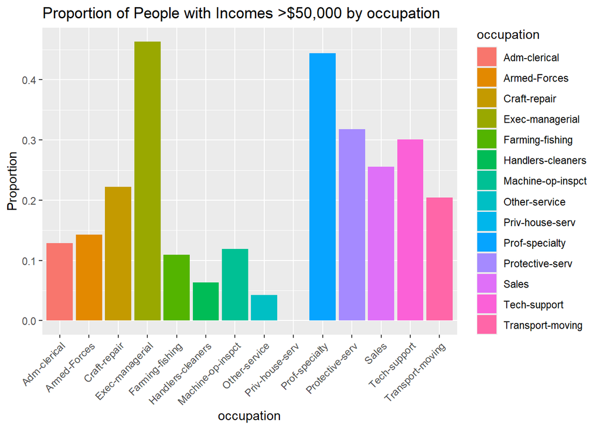

```r
proportions <- train %>%
  group_by(occupation) %>%
  summarise(proportion = sum(income == ">50K") / n())

#barplot of the proportion of wealth people for each occupation
ggplot(proportions, aes(x = occupation, y = proportion, fill = occupation)) +
  geom_bar(stat = "identity") +
  labs(title = "Proportion of People with Incomes >$50,000 by occupation",
       y = "Proportion") +
  theme(axis.text.x = element_text(angle = 45, hjust = 1))  # Rotate x-axis labels for better readability
```

As there are many categories, we divide them into groups taking into account the value of the proportion of individuals who earn above 50k a year:

**High-paid:** Exec-managerial and Prof-specialty

**Medium-paid:** Armed-Forces, Protective-serv, Craft-repair, Sales, Tech-support

**Low-paid:** Adm-clerical, Farming-fishing, Machine-op-inspct, Transport-moving

**Very-low-paid:** Handlers-cleaners, Other-service, Priv-house-serv

```r
#Rearranging occupation categories
train <- train %>%
  mutate(
    occupation = ifelse(occupation %in% c("Exec-managerial", "Prof-specialty"), "High-paid",
                 ifelse(occupation %in% c("Armed-Forces", "Protective-serv", "Craft-repair","Sales","Tech-support"), "Medium-paid",
                  ifelse(occupation %in% c("Adm-clerical", "Farming-fishing","Transport-moving","Machine-op-inspct"), "Low-paid",
                  ifelse(occupation %in% c("Handlers-cleaners", "Other-service","Priv-house-serv"), "Very-low-paid", occupation))))
  )
train$occupation <- factor(train$occupation)


#test data
test_imputed<- test_imputed %>%
  mutate(
    occupation = ifelse(occupation %in% c("Exec-managerial", "Prof-specialty"), "High-paid",
                 ifelse(occupation %in% c("Armed-Forces", "Protective-serv", "Craft-repair","Sales","Tech-support"), "Medium-paid",
                  ifelse(occupation %in% c("Adm-clerical", "Farming-fishing","Transport-moving","Machine-op-inspct"), "Low-paid",
                  ifelse(occupation %in% c("Handlers-cleaners", "Other-service","Priv-house-serv"), "Very-low-paid", occupation))))
  )
test_imputed$occupation <- factor(test_imputed$occupation)
```

#### Education

```r
#observations corresponding to each category of occupation

table(train$education.num)
```

```
##
##    1    2    3    4    5    6    7    8    9   10   11   12   13   14   15   16
##   37  116  240  445  362  670  836  294 7338 5138  969  762 3733 1196  390  267
```

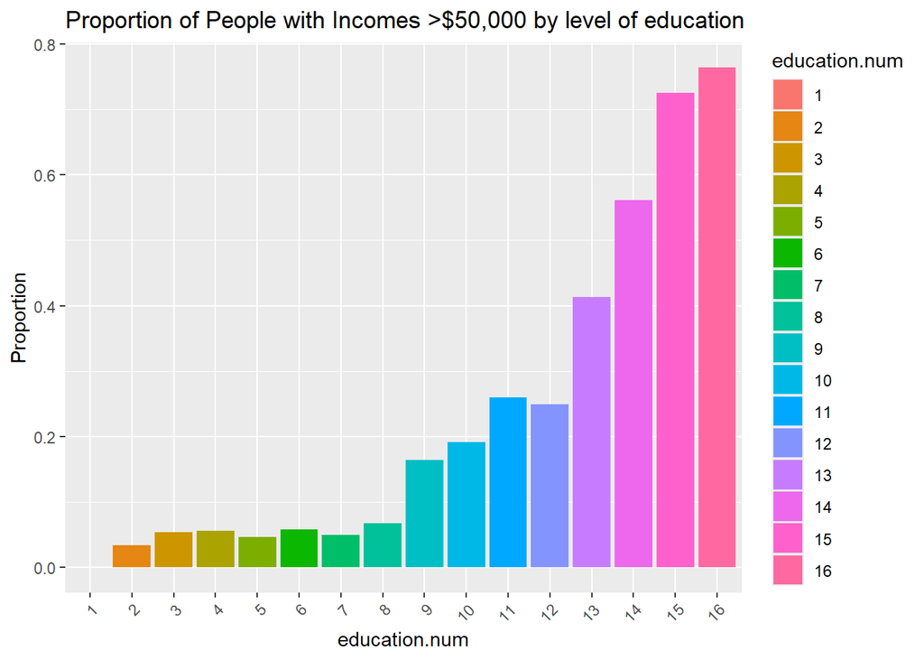

```r
proportions <- train %>%
  group_by(education.num) %>%
  summarise(proportion = sum(income == ">50K") / n())

#barplot of the proportion of wealth people for each occupation
ggplot(proportions, aes(x = education.num, y = proportion, fill = education.num)) +
  geom_bar(stat = "identity") +
  labs(title = "Proportion of People with Incomes >$50,000 by level of education",
       y = "Proportion") +
  theme(axis.text.x = element_text(angle = 45, hjust = 1))  # Rotate x-axis labels for better readability
```

In this barplot it is reflected the fact that if an individual has a very high level of education, its more likely that he or she earns more than $50$k$\$$ a year. We can group all the observations of “education.num” in four categories:

**Low education:** Includes the first 8 levels of education.

**Medium education:** Covers from level 9 to 12.

**High education:** Covers levels 13 and 14.

**Vey high education** Levels 15 and 16.

```r
#Change the name education.num to education.levels
train <- train %>% rename(education.level = education.num)
test_imputed <- test_imputed %>% rename(education.level = education.num)

#Change the categories
train <- train %>%
  mutate(
    education.level = ifelse(education.level %in% c(1:8), "Low",
                 ifelse(education.level %in% c(9:12), "Medium",
                  ifelse(education.level %in% c(13,14), "High",
                  ifelse(education.level %in% c(15,16), "Very high", education.level))))
  )
#Transform it into a factor
train$education.level <- factor(train$education.level)


#Change the categories
test_imputed <- test_imputed %>%
  mutate(
    education.level = ifelse(education.level %in% c(1:8), "Low",
                 ifelse(education.level %in% c(9:12), "Medium",
                  ifelse(education.level %in% c(13,14), "High",
                  ifelse(education.level %in% c(15,16), "Very high", education.level))))
  )
#Transform it into a factor
test_imputed$education.level <- factor(test_imputed$education.level)
```

### Numerical variables

To better understand the distribution and correlation among numerical variables, we present a pairs plot depicting all the numeric features. Additionally, we utilize colors to differentiate whether the income is greater or smaller than 50.000$\$$.

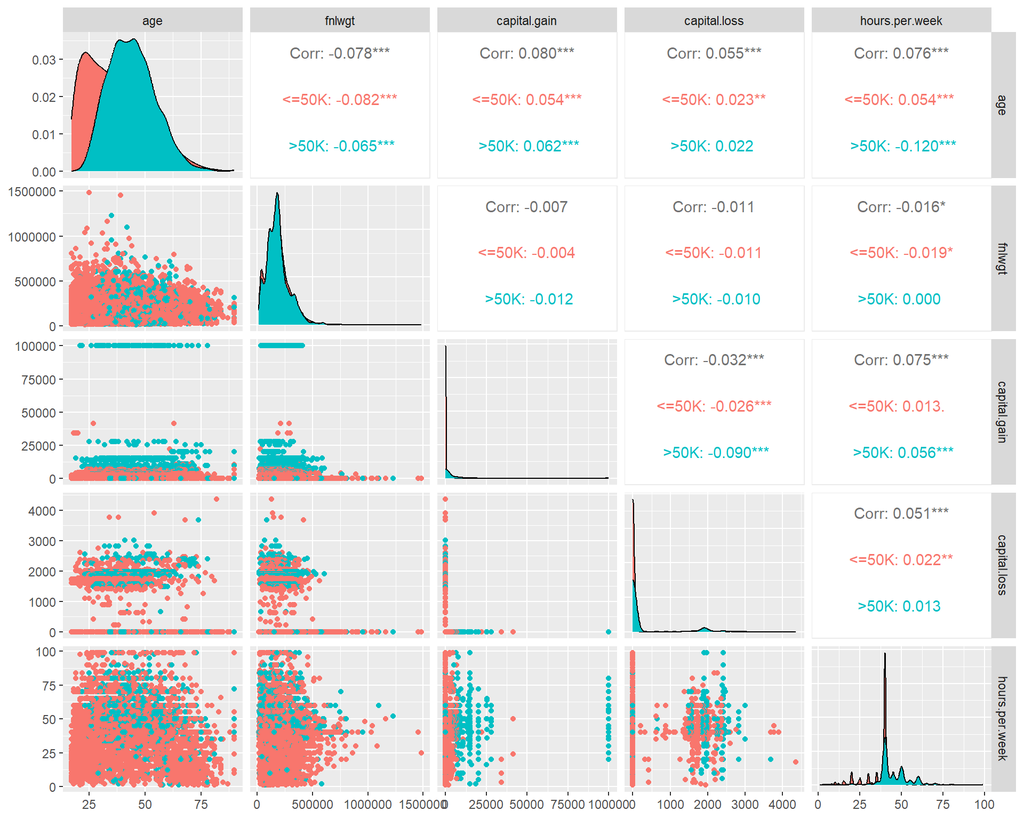

```r
numeric_columns <- c('age','fnlwgt','capital.gain','capital.loss',
                    'hours.per.week')
ggpairs(data = train , columns = numeric_columns, aes(color = income))
```

We complement the pairs plot with a correlation heatmap.

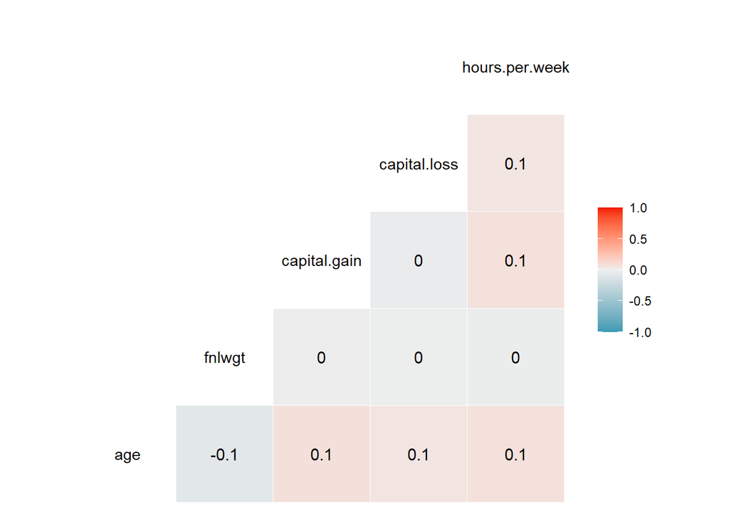

```r
ggcorr(train[,numeric_columns], label = TRUE)
```

From the pairs plot and the correlation heatmap, it is evident that the correlation among pairs of numerical variables is very low, almost approaching zero. Furthermore, we can derive some interesting insights from the pairs plot. For instance, the feature ‘age’ seems to play a significant role in determining wealth status, which aligns with logical expectations. Typically, younger individuals tend to earn lower salaries initially, but as they gain experience and age, their earning potential tends to increase. Additionally, as expected, the probability of earning more than 50.000$\$$ per year increases with the number of working hours per week. However, the peak is reached somewhere between 40 and 50 hours per week.

As observed in the pairs plot, the features ‘capital.gain’ and ‘capital.loss’ are highly skewed to the right. Therefore, we analyze them in more detail by examining their histograms.

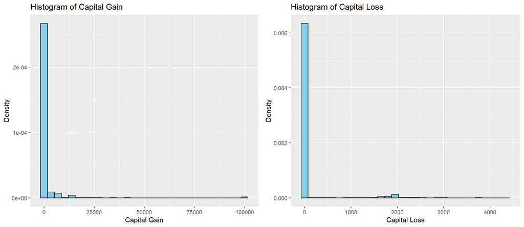

```r
#Histogram of capital.gain
plot1 <- ggplot(train, aes(x = capital.gain)) +
  geom_histogram(aes(y = ..density..), fill = "skyblue", color = "black") +
  labs(title = "Histogram of Capital Gain",
       x = "Capital Gain",
       y = "Density")

#Histogram of capital.loss
plot2 <- ggplot(train, aes(x = capital.loss)) +
  geom_histogram(aes(y = ..density..), fill = "skyblue", color = "black") +
  labs(title = "Histogram of Capital Loss",
       x = "Capital Loss",
       y = "Density")

grid.arrange(plot1, plot2, ncol = 2)
```

```r
cat('Proportion of zeros in capital.gain values:', dim(train[train$capital.gain == 0, ])[1]/dim(train)[1])
```

```
## Proportion of zeros in capital.gain values: 0.9165533
```

```r
cat('Proportion of zeros in capital.loss values:', dim(train[train$capital.loss == 0, ])[1]/dim(train)[1])
```

```
## Proportion of zeros in capital.loss values: 0.9530119
```

From the histograms, it can be observed that both variables are zero-inflated. Therefore, it may be a good idea to convert them into binary features. However, before doing so, we need to determine whether the non-zero values have a significant impact on the output.

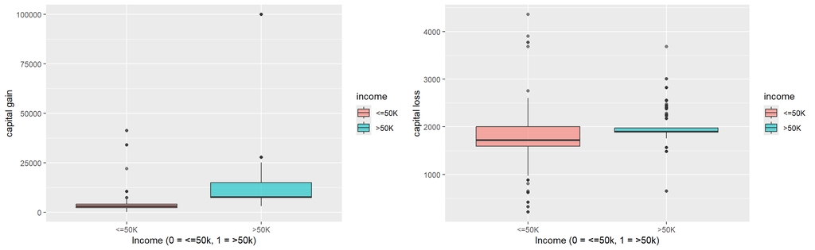

```r
 boxplot1 <- ggplot(train[train$capital.gain != 0,], aes(x = income , y = capital.gain, fill = income)) +
       geom_boxplot(alpha = 0.6) +
       labs(x = "Income (0 = <=50k, 1 = >50k)", y = "capital gain")

boxplot2 <- ggplot(train[train$capital.loss != 0,], aes(x = income , y = capital.loss, fill = income)) +
       geom_boxplot(alpha = 0.6) +
       labs(x = "Income (0 = <=50k, 1 = >50k)", y = "capital loss")

grid.arrange(boxplot1, boxplot2, ncol = 2)
```

Based on these boxplots, it seems that the values of “capital.gain” and “capital.loss” may be important for determining the classes, so we keep these features as they are.

Finally, we display a barplot showing the proportion of individuals in the training dataset with an annual salary above 50.000$\$$ and the proportion of people with salaries below.

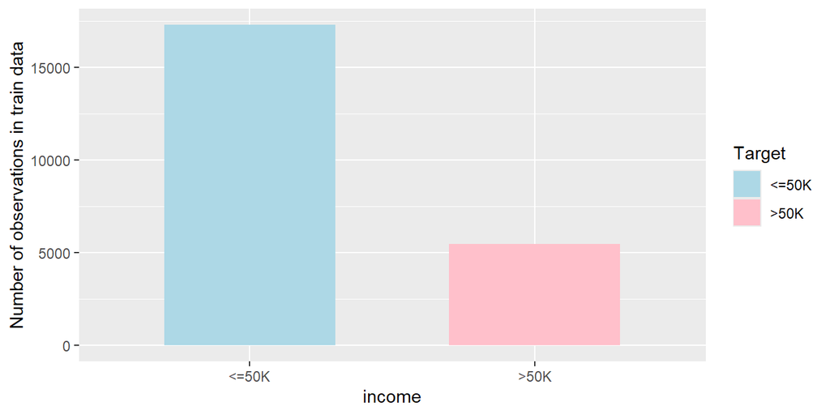

```r
count_1 <- sum(train$income == ">50K")
count_0 <- sum(train$income == "<=50K")
#dataframe with the counts
counts_train <- data.frame(Target = c(">50K", "<=50K"), Count = c(count_1, count_0))
#create the barplot
ggplot(counts_train, aes(x = Target, y = Count, fill = Target)) +
  geom_bar(stat = "identity", width = 0.6) +
  labs(x = "income", y = "Number of observations in train data") +
   scale_fill_manual(values = c(">50K" = "pink", "<=50K" = "lightblue"))
```

It is seen that the target variable “income” is imbalanced. However, the degree of imbalance is not very big and taking into account that the dataset is big and there are enough individuals belonging to each class, we do not perform oversampling or subsampling techniques to balance the classes.

## Machine Learning algorithms

As seen before, determining if an individual earns more than $50.000\$$ annually can be important several applications such as economic research and statistical studies about the population. In those cases, it is important to train a model as much accurate as possible, so in this section, we focus on training models focusing on maximizing the accuracy.

#### Logistic regression

Before training any supervised ML algorithm, first of all, we fit a logistic regression model and set the results as a benchmark to asses the performance of the future ML algorithms. As seen in the EDA section, the dimension of the dataset is not very high and the correlation among the predictors is low, so we fit a logistic regression model without penalization. One of the advantages of logistic regression compared to more shophisticated ML algorithms is that is easy to explain and to interpret.

```r
#Change the names of the factors to compute the probabilities
#as we want to exctract the probabilities we change the names of the levels of
#target variable
levels(train$income) <- c("under50K", "over50K")
levels(test_imputed$income) <- c("under50K", "over50K")

#Standardize the variables of the dataset for some ML algorithms. Standardize them only using the training data in order to avoid data leakage
preprocessor <- preProcess(train[, numeric_columns], method = c("center", "scale"))
train[, numeric_columns] <- predict(preprocessor, train[, numeric_columns])
test_imputed[, numeric_columns] <- predict(preprocessor, test_imputed[, numeric_columns])
```

```r
logit_model <- glm(income ~., family = 'binomial', data = train)
#Show a summary of the model
summary(logit_model)
```

```
##
## Call:
## glm(formula = income ~ ., family = "binomial", data = train)
##
## Coefficients:
##                                  Estimate Std. Error z value Pr(>|z|)
## (Intercept)                      -1.04187    0.18721  -5.565 2.62e-08 ***
## age                               0.30629    0.02460  12.452  < 2e-16 ***
## workclassLocal-gov               -0.74968    0.12689  -5.908 3.46e-09 ***
## workclassNo-salary              -11.90260  114.69905  -0.104 0.917350
## workclassPrivate                 -0.60163    0.10598  -5.677 1.37e-08 ***
## workclassSelf-emp-inc            -0.51240    0.13925  -3.680 0.000234 ***
## workclassSelf-emp-not-inc        -1.27742    0.12301 -10.385  < 2e-16 ***
## workclassState-gov               -0.77698    0.14230  -5.460 4.76e-08 ***
## fnlwgt                            0.10561    0.02104   5.020 5.16e-07 ***
## education.levelLow               -2.19768    0.10333 -21.269  < 2e-16 ***
## education.levelMedium            -0.90380    0.05111 -17.684  < 2e-16 ***
## education.levelVery high          0.75514    0.12027   6.279 3.41e-10 ***
## marital.statusSpouse              2.27652    0.30167   7.546 4.47e-14 ***
## occupationLow-paid               -0.95804    0.06102 -15.700  < 2e-16 ***
## occupationMedium-paid            -0.49818    0.05367  -9.283  < 2e-16 ***
## occupationVery-low-paid          -1.46792    0.09825 -14.941  < 2e-16 ***
## relationshipOther-relative       -0.88762    0.29054  -3.055 0.002250 **
## relationshipOwn-child            -1.32195    0.17628  -7.499 6.42e-14 ***
## relationshipSpouse               -0.02716    0.30624  -0.089 0.929318
## relationshipUnmarried            -0.16481    0.11117  -1.482 0.138226
## raceWhite-Asian                   0.21273    0.08146   2.612 0.009014 **
## sexMale                           0.02378    0.06009   0.396 0.692294
## capital.gain                      2.30935    0.08879  26.009  < 2e-16 ***
## capital.loss                      0.26582    0.01766  15.053  < 2e-16 ***
## hours.per.week                    0.35523    0.02278  15.597  < 2e-16 ***
## regionCentral and South America  -0.42634    0.19151  -2.226 0.026002 *
## regionEastern Europe              0.15203    0.37433   0.406 0.684640
## regionNorth America               0.24048    0.13007   1.849 0.064484 .
## regionWestern Europe              0.29761    0.20716   1.437 0.150828
## ---
## Signif. codes:  0 '***' 0.001 '**' 0.01 '*' 0.05 '.' 0.1 ' ' 1
##
## (Dispersion parameter for binomial family taken to be 1)
##
##     Null deviance: 25165  on 22792  degrees of freedom
## Residual deviance: 14872  on 22764  degrees of freedom
## AIC: 14930
##
## Number of Fisher Scoring iterations: 12
```

Based on the coefficients of the fitted logistic regression model, we identify the feature values in the dataset associated with individuals likely to earn more than 50.000$\$$ a year.

**Age:** As older, the better.

**fnlwgt:** The greater, the better.

**Education:** High level of education (doctorate level).

**Marital Status:** Married and with no absent spouse.

**Occupation:** “Exec_managerial” or “Prof-Specialty”

**Relationship:** Not in a family relationship.

**Race:** White and Asian.

**Gender:** Male.

**Capital.gain:** The higher the better.

**Capital.loss:** The higher the better.

**Working hours per week:** The higher the better.

**Region:** Western Europe.

Predictions of the logistic regression model:

```r
probabilities_logit <- predict(logit_model, newdata = test_imputed, type = 'response')
#use p = 0.5 as a naive threshold
predictions_logit <- ifelse(probabilities_logit > 0.5,1,0)
predictions_logit <- factor(predictions_logit)
levels(predictions_logit) <- c("under50K", "over50K")
conf_matrix <- confusionMatrix(data = predictions_logit, reference = test_imputed$income)
```

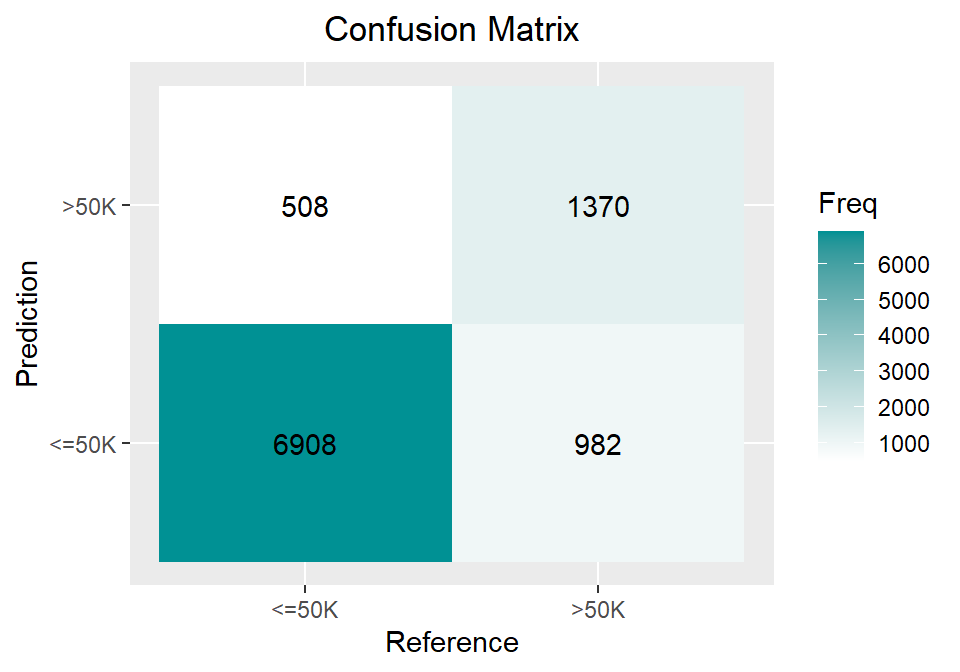

```r
#plot the confusion matrix and several quantities
conf_matrix_table <- as.data.frame(conf_matrix$table)


ggplot(conf_matrix_table, aes(x = Reference, y = Prediction,fill= Freq)) +
        geom_tile() + geom_text(aes(label=Freq)) +
        scale_fill_gradient(low="white", high="#009194") +
        labs(x = "Reference",y = "Prediction") +
        scale_x_discrete(labels=c("<=50K",">50K")) +
        scale_y_discrete(labels=c("<=50K", ">50K")) +
        ggtitle("Confusion Matrix") +
        theme(plot.title = element_text(hjust = 0.5))
```

```r
#dataframe with some metrics
metrics_df <- data.frame(
  Value = c(conf_matrix$byClass["Sensitivity"],
            conf_matrix$byClass["Specificity"],
            conf_matrix$overall["Kappa"],
            conf_matrix$overall["Accuracy"])
)

#show the dataframe
print(metrics_df)
```

```
##                 Value
## Sensitivity 0.9314995
## Specificity 0.5824830
## Kappa       0.5519615
## Accuracy    0.8474611
```

The accuracy and kappa are good although they can be better. Moreover, the specificity is low and depending on the purpose of the classification it may be need to be improven. Anyway, the results are quite good for a logistic regression model.

#### KNN

The first ML algorithm is KNN, which is not very suitable for this dataset, since most of the features are categorical and the numerical ones are not related to geospatial data. As KNN is a ML algorithm sensitive to the scale of the features, it is advisable to scale them before training the model. In this case, the variables were standardized at the beginning of this section.

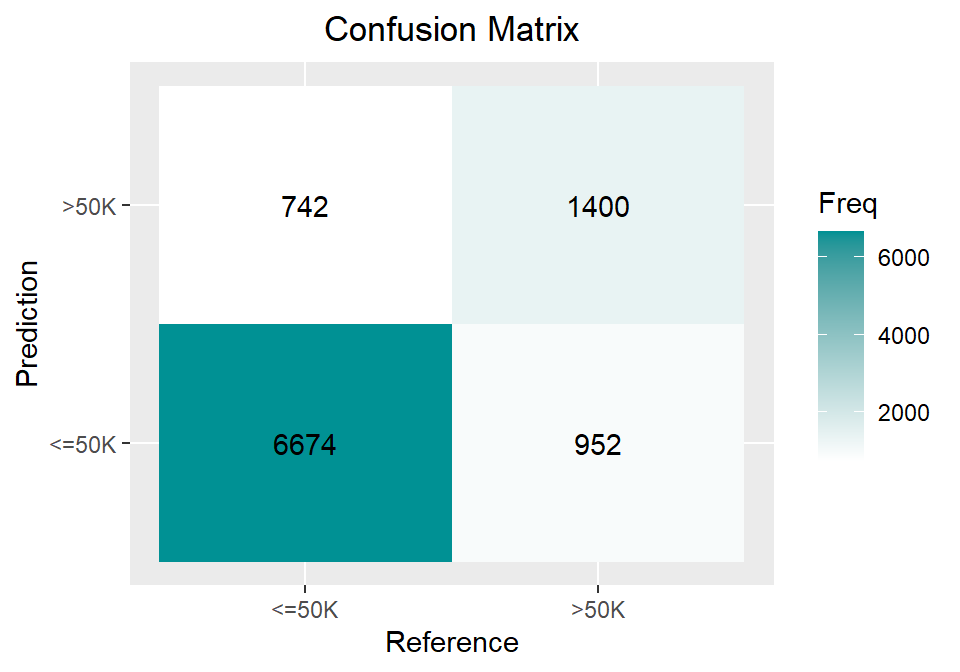

```r
knn_model <- kknn(income ~ ., train = train, test = test_imputed, k = 5)

#predictions on the trained model
knn_predictions <- fitted(knn_model)

#confusion matrix of the model
conf_matrix <- confusionMatrix(data = knn_predictions, reference = test_imputed$income)
#plot the confusion matrix and several quantities
conf_matrix_table <- as.data.frame(conf_matrix$table)


ggplot(conf_matrix_table, aes(x = Reference, y = Prediction,fill= Freq)) +
        geom_tile() + geom_text(aes(label=Freq)) +
        scale_fill_gradient(low="white", high="#009194") +
        labs(x = "Reference",y = "Prediction") +
        scale_x_discrete(labels=c("<=50K",">50K")) +
        scale_y_discrete(labels=c("<=50K", ">50K")) +
        ggtitle("Confusion Matrix") +
        theme(plot.title = element_text(hjust = 0.5))
```

```r
#dataframe with some metrics
metrics_df <- data.frame(
  Value = c(conf_matrix$byClass["Sensitivity"],
            conf_matrix$byClass["Specificity"],
            conf_matrix$overall["Kappa"],
            conf_matrix$overall["Accuracy"])
)

#show the dataframe
print(metrics_df)
```

```
##                 Value
## Sensitivity 0.8999461
## Specificity 0.5952381
## Kappa       0.5107541
## Accuracy    0.8265766
```

The performance is in general, worse than the logistic regression model although the specificity is a little bit higher. To improve the model,we perform hyperparameter tunning on the number of neighbors $k$, the type of distance that is computed, and the distribution of the weights assigned to each neighbor:

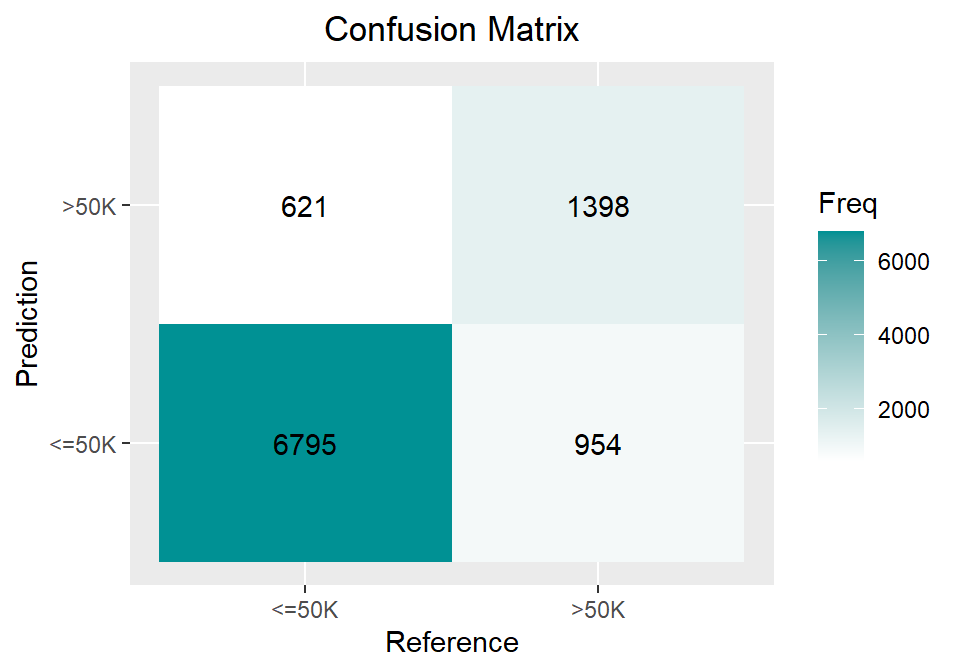

```r
control <- trainControl(method = "cv", number = 5, classProbs = TRUE)

#grid for the searching hyperparameters
grid <- expand.grid(kmax = c(5,7,9,11,13,15,17),
                    distance = c(1,2,3),
                    kernel = c('rectangular', 'gaussian'))

#search of hyperparameters with crossvalidation
knn_model_hpo <- train(income ~ .,
                   data = train,
                   method = "kknn",
                   trControl = control,
                   tuneGrid = grid,
                   metric = 'Accuracy')


# Make predictions on the test data
predictions_knn_hpo <- predict(knn_model_hpo, newdata = test_imputed)

#confusion matrix of the model
conf_matrix <- confusionMatrix(data = predictions_knn_hpo, reference = test_imputed$income)
#plot the confusion matrix and several quantities
conf_matrix_table <- as.data.frame(conf_matrix$table)


ggplot(conf_matrix_table, aes(x = Reference, y = Prediction,fill= Freq)) +
  geom_tile() + geom_text(aes(label=Freq)) +
  scale_fill_gradient(low="white", high="#009194") +
  labs(x = "Reference",y = "Prediction") +
  scale_x_discrete(labels=c("<=50K",">50K")) +
  scale_y_discrete(labels=c("<=50K", ">50K")) +
  ggtitle("Confusion Matrix") +
  theme(plot.title = element_text(hjust = 0.5))
```

```r
#Hyperparameters of the model
knn_model_hpo$bestTune
```

```
##    kmax distance      kernel
## 37   17        1 rectangular
```

```r
#dataframe with some metrics
metrics_df <- data.frame(
  Value = c(conf_matrix$byClass["Sensitivity"],
            conf_matrix$byClass["Specificity"],
            conf_matrix$overall["Kappa"],
            conf_matrix$overall["Accuracy"])
)

#show the dataframe
print(metrics_df)
```

```
##                 Value
## Sensitivity 0.9162621
## Specificity 0.5943878
## Kappa       0.5365882
## Accuracy    0.8387592
```

The hyperparameters obtained are $k = 17$, $p=1$ which corresponds to compute the manhattan distance between points and a rectangular distribution for the weights which means that all the neighbors are given the same weight. Although the obtained performance has improved slightly, the accuracy remains smaller than that of logistic regression. It is important to emphasize that due to the dataset size, is a computationally expensive method.

##### Supported vector machines

As a first SVM algorithm, we fit a linear SVM with a default value of $1$ for the hyperparameter $C$ which controls the overfitting.

```r
svm_linear_model <- svm(income ~., data = train, kernel = 'linear')
predictions_svm_linear <- predict(svm_linear_model, newdata = test_imputed)

conf_matrix <- confusionMatrix(data = predictions_svm_linear, reference = test_imputed$income)
```

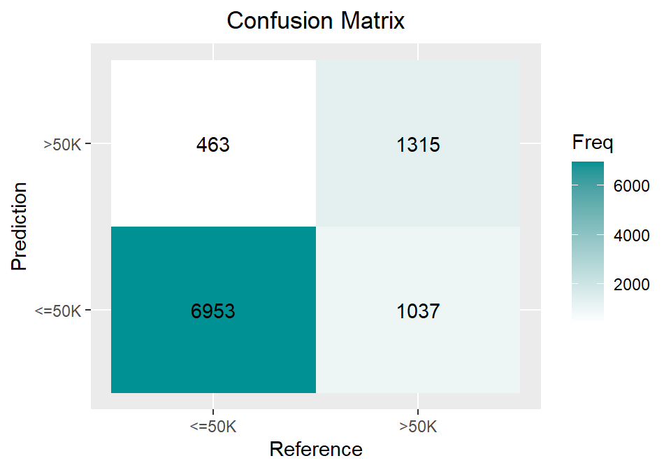

```r
#plot the confusion matrix and several quantities
conf_matrix_table <- as.data.frame(conf_matrix$table)


ggplot(conf_matrix_table, aes(x = Reference, y = Prediction,fill= Freq)) +
        geom_tile() + geom_text(aes(label=Freq)) +
        scale_fill_gradient(low="white", high="#009194") +
        labs(x = "Reference",y = "Prediction") +
        scale_x_discrete(labels=c("<=50K",">50K")) +
        scale_y_discrete(labels=c("<=50K", ">50K")) +
        ggtitle("Confusion Matrix") +
        theme(plot.title = element_text(hjust = 0.5))
```

```r
#dataframe with some metrics
metrics_df <- data.frame(
  Value = c(conf_matrix$byClass["Sensitivity"],
            conf_matrix$byClass["Specificity"],
            conf_matrix$overall["Kappa"],
            conf_matrix$overall["Accuracy"])
)

#show the dataframe
print(metrics_df)
```

```
##                 Value
## Sensitivity 0.9375674
## Specificity 0.5590986
## Kappa       0.5418118
## Accuracy    0.8464373
```

The accuracy obtained is very similar to the one obtained with logistic regression, but slightly smaller. To try to improve the accuracy we consider two different kernels: “polynomial” and “radial”, compare them with the linear one and then, we do hyperparameter tunning of that model.

**Polynomial kernel:**

This kernel maps the data into a higher space using a polynomial function, and the degree of the polynomial is an hyperparameter. In the SVM algorithm of `e1071`, the default degree is $3$.

```r
svm_polynom_model <- svm(income ~., data = train, kernel = 'polynomial')
predictions_svm_polynom <- predict(svm_polynom_model, newdata = test_imputed)

conf_matrix <- confusionMatrix(data = predictions_svm_polynom, reference = test_imputed$income)
```

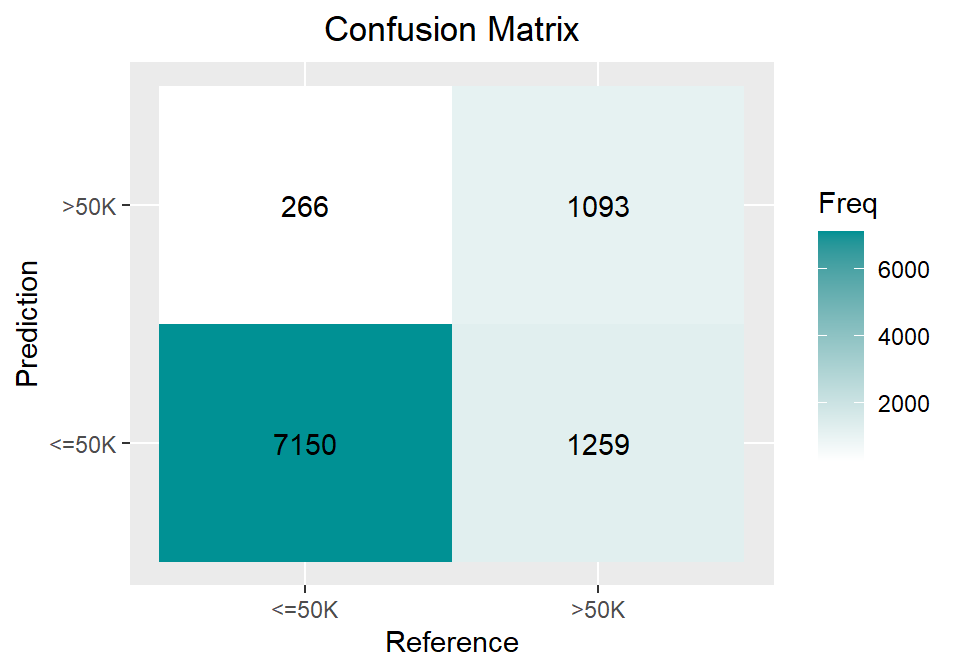

```r
#plot the confusion matrix and several quantities
conf_matrix_table <- as.data.frame(conf_matrix$table)


ggplot(conf_matrix_table, aes(x = Reference, y = Prediction,fill= Freq)) +
        geom_tile() + geom_text(aes(label=Freq)) +
        scale_fill_gradient(low="white", high="#009194") +
        labs(x = "Reference",y = "Prediction") +
        scale_x_discrete(labels=c("<=50K",">50K")) +
        scale_y_discrete(labels=c("<=50K", ">50K")) +
        ggtitle("Confusion Matrix") +
        theme(plot.title = element_text(hjust = 0.5))
```

```r
#dataframe with some metrics
metrics_df <- data.frame(
  Value = c(conf_matrix$byClass["Sensitivity"],
            conf_matrix$byClass["Specificity"],
            conf_matrix$overall["Kappa"],
            conf_matrix$overall["Accuracy"])
)

#show the dataframe
print(metrics_df)
```

```
##                 Value
## Sensitivity 0.9641316
## Specificity 0.4647109
## Kappa       0.5010703
## Accuracy    0.8438780
```

The accuracy is worse than the accuracy obtained with the linear kernel.

**Radial kernel:**

A radial kernel SVM transforms data into a high-dimensional space using a radial basis function such as a Gaussian function to compute the similarity between pairs of observations, with a parameter $\gamma = \frac{1}{\sigma}$ controlling the flexibility of the model by adjusting the smoothness of the decision boundary. By default, $\sigma = 0.1$

```r
svm_radial_model <- svm(income ~., data = train, kernel = 'radial')
predictions_svm_radial <- predict(svm_radial_model, newdata = test_imputed)

conf_matrix <- confusionMatrix(data = predictions_svm_radial, reference = test_imputed$income)
```

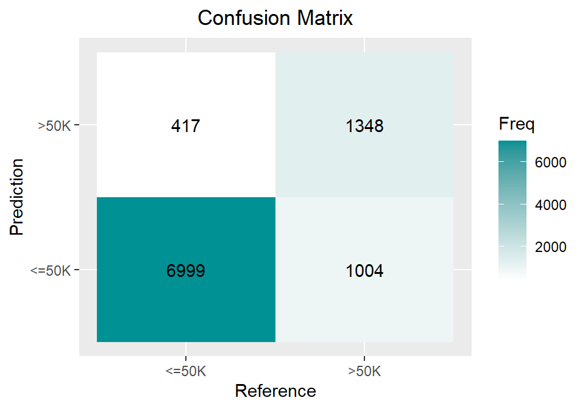

```r
#plot the confusion matrix and several quantities
conf_matrix_table <- as.data.frame(conf_matrix$table)


ggplot(conf_matrix_table, aes(x = Reference, y = Prediction,fill= Freq)) +
        geom_tile() + geom_text(aes(label=Freq)) +
        scale_fill_gradient(low="white", high="#009194") +
        labs(x = "Reference",y = "Prediction") +
        scale_x_discrete(labels=c("<=50K",">50K")) +
        scale_y_discrete(labels=c("<=50K", ">50K")) +
        ggtitle("Confusion Matrix") +
        theme(plot.title = element_text(hjust = 0.5))
```

```r
#dataframe with some metrics
metrics_df <- data.frame(
  Value = c(conf_matrix$byClass["Sensitivity"],
            conf_matrix$byClass["Specificity"],
            conf_matrix$overall["Kappa"],
            conf_matrix$overall["Accuracy"])
)

#show the dataframe
print(metrics_df)
```

```
##                 Value
## Sensitivity 0.9437702
## Specificity 0.5731293
## Kappa       0.5650477
## Accuracy    0.8545250
```

By looking at the results obtained using the different kernels, the one with highest accuracy is the SVM with radial kernel. Its hyperparameters are $\sigma$ and $C$

```r
#grid parameter
grid <- expand.grid(sigma = c(0.01,0.1,0.5,1),
                    C = c(0.1,0.2,0.5,1,10))

#define the control of training (In this case, the probabilities are not well defined)
ctrl <- trainControl(
  method = "cv",
  number = 5
)


model_svm_hpo <- train(
  income ~ .,
  data = train,
  method = "svmRadial",
  trControl = ctrl,
  tuneGrid = grid,
  metric = 'Accuracy'
)


# Make predictions on the test data
predictions_svm_hpo <- predict(model_svm_hpo, newdata = test_imputed)

#confusion matrix of the model
conf_matrix <- confusionMatrix(data = predictions_svm_hpo, reference = test_imputed$income)
#plot the confusion matrix and several quantities
conf_matrix_table <- as.data.frame(conf_matrix$table)
```

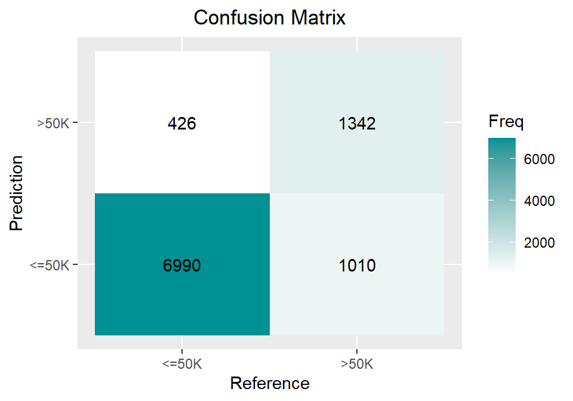

```r
ggplot(conf_matrix_table, aes(x = Reference, y = Prediction,fill= Freq)) +
  geom_tile() + geom_text(aes(label=Freq)) +
  scale_fill_gradient(low="white", high="#009194") +
  labs(x = "Reference",y = "Prediction") +
  scale_x_discrete(labels=c("<=50K",">50K")) +
  scale_y_discrete(labels=c("<=50K", ">50K")) +
  ggtitle("Confusion Matrix") +
  theme(plot.title = element_text(hjust = 0.5))
```

```r
#Hyperparameters of the model
model_svm_hpo$bestTune
```

```
##   sigma  C
## 5  0.01 10
```

```r
#dataframe with some metrics
metrics_df <- data.frame(
  Value = c(conf_matrix$byClass["Sensitivity"],
            conf_matrix$byClass["Specificity"],
            conf_matrix$overall["Kappa"],
            conf_matrix$overall["Accuracy"])
)

#show the dataframe with the metrics
print(metrics_df)
```

```
##                 Value
## Sensitivity 0.9425566
## Specificity 0.5705782
## Kappa       0.5606655
## Accuracy    0.8529894
```

The hyperparameters obtained are $C = 10$ and $\sigma = 0.01$. The accuracy is slightly lower than the one obtained using default hyperparameters, which may be due to the fact that the hyperparameters are selected using cross-validation, while the accuracy is measured using a train-test split approach. To improve performance, a larger grid could be used. However, due to the size of the dataset, this would be very computationally expensive

##### Decision trees

We train a decision tree using the `rpart` library in R. Decision trees are suitable for this dataset as they can handle both numeric and categorical variables. Initially, we train a model with the default value of ‘maxdepth’ (maxdepth = 30), which is the main hyperparameter and controls the depth of the tree. A high value of “maxdepth” can lead to overfitting.

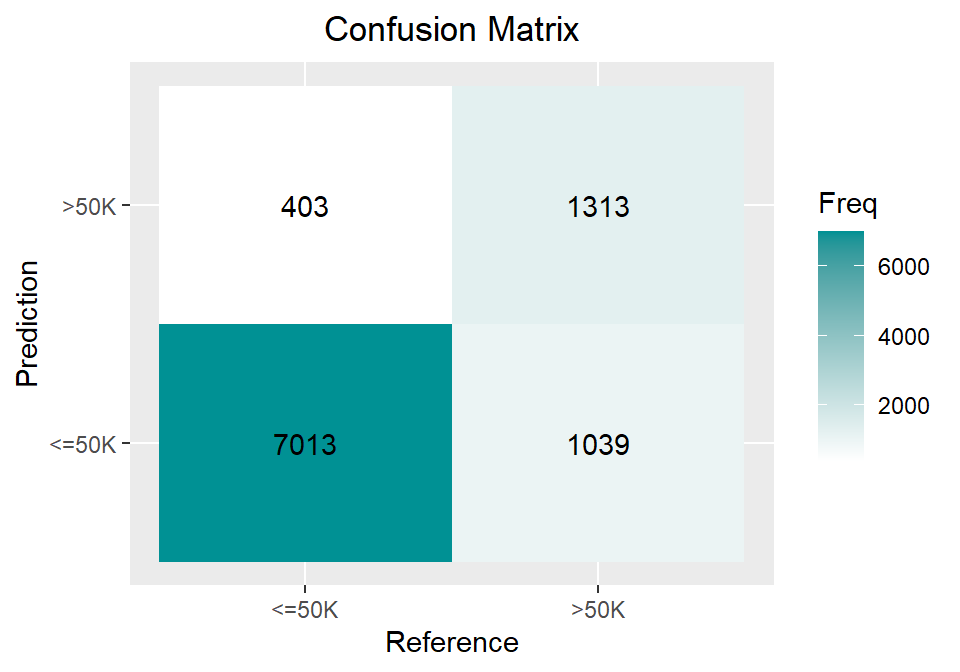

```r
tree_model <- rpart(income ~ ., data = train, method = 'class')

#predictions on the trained model
tree_predictions <- predict(tree_model, newdata = test_imputed, type = 'class')

#confusion matrix of the model
conf_matrix <- confusionMatrix(data = tree_predictions, reference = test_imputed$income)
#plot the confusion matrix and several quantities
conf_matrix_table <- as.data.frame(conf_matrix$table)


ggplot(conf_matrix_table, aes(x = Reference, y = Prediction,fill= Freq)) +
        geom_tile() + geom_text(aes(label=Freq)) +
        scale_fill_gradient(low="white", high="#009194") +
        labs(x = "Reference",y = "Prediction") +
        scale_x_discrete(labels=c("<=50K",">50K")) +
        scale_y_discrete(labels=c("<=50K", ">50K")) +
        ggtitle("Confusion Matrix") +
        theme(plot.title = element_text(hjust = 0.5))
```

```r
#dataframe with some metrics
metrics_df <- data.frame(
  Value = c(conf_matrix$byClass["Sensitivity"],
            conf_matrix$byClass["Specificity"],
            conf_matrix$overall["Kappa"],
            conf_matrix$overall["Accuracy"])
)

#show the dataframe
print(metrics_df)
```

```
##                 Value
## Sensitivity 0.9456580
## Specificity 0.5582483
## Kappa       0.5551609
## Accuracy    0.8523751
```

The accuracy obtained by this model is higher than the one achieved with logistic regression. To improve the performance, we do hyperparameter tunning of ‘maxdepth’. Usually, decision trees are ML methods with small bias and high variance, so choosing the optimal value of maxdepth can help in reducing the variance.

```r
#grid parameter
grid <- expand.grid(
  maxdepth = seq(2,20, by = 1)
)

#define the control of training
ctrl <- trainControl(
  method = "cv",
  number = 5,
  classProbs = TRUE
)


model_tree_hpo <- train(
  income ~ .,
  data = train,
  method = "rpart2",
  trControl = ctrl,
  tuneGrid = grid,
  metric = 'Accuracy'
)


# Make predictions on the test data
predictions_tree_hpo <- predict(model_tree_hpo, newdata = test_imputed)

#confusion matrix of the model
conf_matrix <- confusionMatrix(data = predictions_tree_hpo, reference = test_imputed$income)
#plot the confusion matrix and several quantities
conf_matrix_table <- as.data.frame(conf_matrix$table)
```

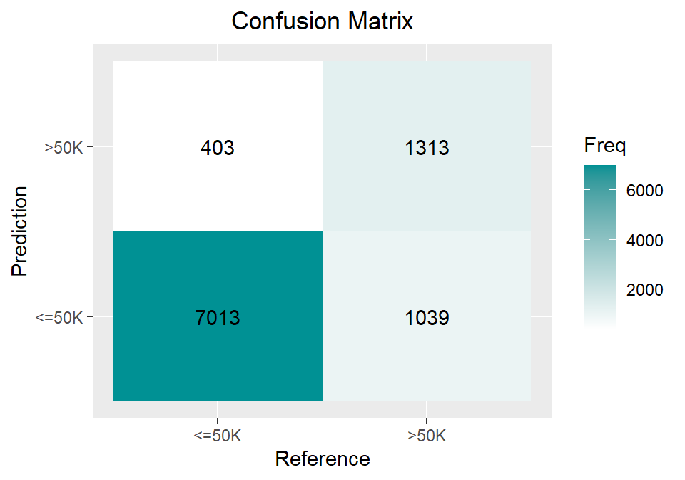

```r
ggplot(conf_matrix_table, aes(x = Reference, y = Prediction,fill= Freq)) +
  geom_tile() + geom_text(aes(label=Freq)) +
  scale_fill_gradient(low="white", high="#009194") +
  labs(x = "Reference",y = "Prediction") +
  scale_x_discrete(labels=c("<=50K",">50K")) +
  scale_y_discrete(labels=c("<=50K", ">50K")) +
  ggtitle("Confusion Matrix") +
  theme(plot.title = element_text(hjust = 0.5))
```

```r
#Hyperparameters of the model
model_tree_hpo$bestTune
```

```
##   maxdepth
## 6        7
```

```r
#dataframe with some metrics
metrics_df <- data.frame(
  Value = c(conf_matrix$byClass["Sensitivity"],
            conf_matrix$byClass["Specificity"],
            conf_matrix$overall["Kappa"],
            conf_matrix$overall["Accuracy"])
)

#show the dataframe with the metrics
print(metrics_df)
```

```
##                 Value
## Sensitivity 0.9456580
## Specificity 0.5582483
## Kappa       0.5551609
## Accuracy    0.8523751
```

The optimal value of ‘maxdepth’ obtained is $7$. Nevertheless, the accuracy obtained using this value is the same as the one obtained using the default value.

#### Random forest

Random Forest algorithm usually works very well as a classifying ML algorithm for tabular data. It generates quasi independent random decision trees via bootstrap aggregation (bagging) and it classifies a class as the most voted one. The main hyperparameters are: the number of trees (ntree) and the number of variables fed to each tree (mtry) First, we will train a random forest model using `randomForest()` library, which uses the default values $ntry = \sqrt{p}$ where $p$ is the number of predictor variables (in this case, $p=13$) and $ntree =500$.

```r
rf_model <- randomForest(income ~ ., data = train)

#predictions on the trained model
rf_predictions <- predict(rf_model, newdata = test_imputed)

#confusion matrix of the model
conf_matrix <- confusionMatrix(data = rf_predictions, reference = test_imputed$income)
#plot the confusion matrix
conf_matrix_table <- as.data.frame(conf_matrix$table)
```

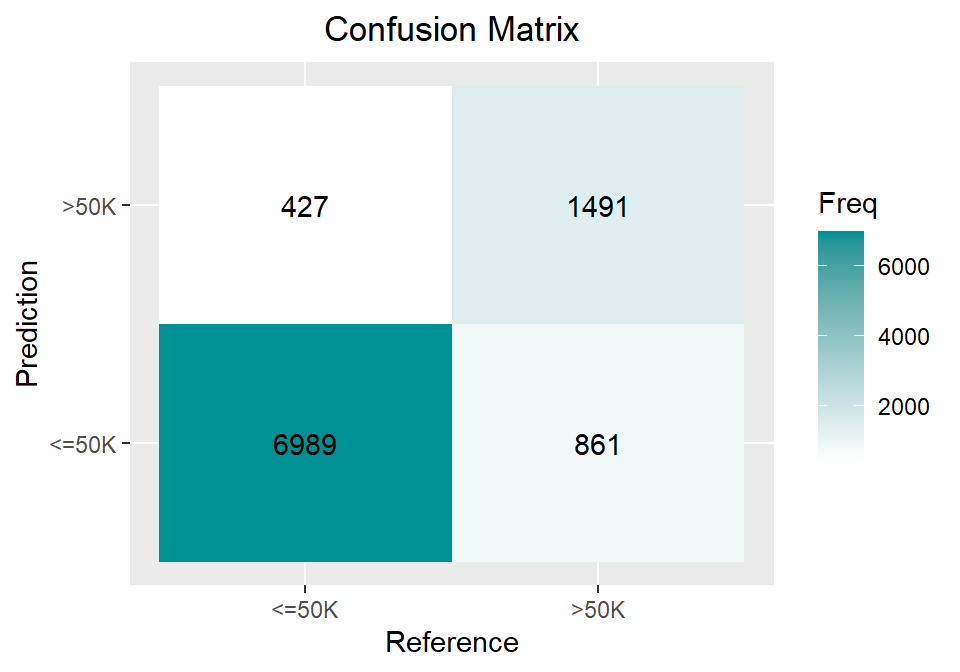

```r
ggplot(conf_matrix_table, aes(x = Reference, y = Prediction,fill= Freq)) +
        geom_tile() + geom_text(aes(label=Freq)) +
        scale_fill_gradient(low="white", high="#009194") +
        labs(x = "Reference",y = "Prediction") +
        scale_x_discrete(labels=c("<=50K",">50K")) +
        scale_y_discrete(labels=c("<=50K", ">50K")) +
        ggtitle("Confusion Matrix") +
        theme(plot.title = element_text(hjust = 0.5))
```

```r
#dataframe with some metrics
metrics_df <- data.frame(
  Value = c(conf_matrix$byClass["Sensitivity"],
            conf_matrix$byClass["Specificity"],
            conf_matrix$overall["Kappa"],
            conf_matrix$overall["Accuracy"])
)

#show the dataframe
print(metrics_df)
```

```
##                 Value
## Sensitivity 0.9424218
## Specificity 0.6339286
## Kappa       0.6151023
## Accuracy    0.8681409
```

```r
#grid parameter
grid <- expand.grid(mtry = seq(1, dim(train[,-1])[2], by = 1))

#define the control of training
ctrl <- trainControl(
  method = "cv",
  number = 5,
  classProbs = TRUE
)


model_rf_hpo <- train(
  income ~ .,
  data = train,
  method = "rf",
  trControl = ctrl,
  tuneGrid = grid,
  metric = 'Accuracy',
  ntree = 2000
)


# Make predictions on the test data
predictions_rf_hpo <- predict(model_rf_hpo, newdata = test_imputed)

#confusion matrix of the model
conf_matrix <- confusionMatrix(data = predictions_rf_hpo, reference = test_imputed$income)
#plot the confusion matrix and several quantities
conf_matrix_table <- as.data.frame(conf_matrix$table)
```

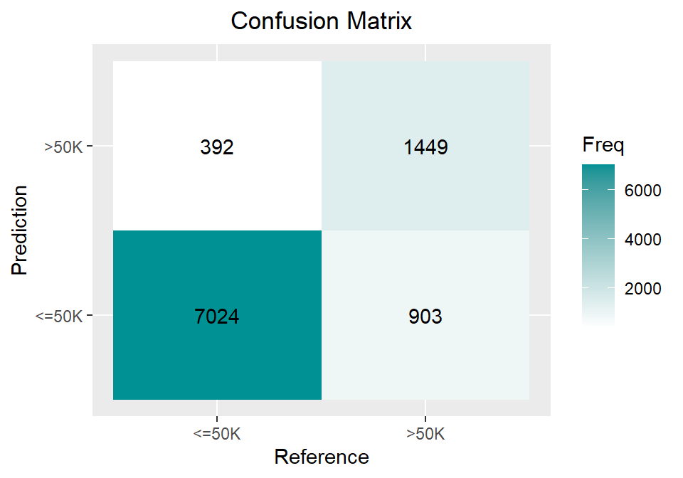

```r
ggplot(conf_matrix_table, aes(x = Reference, y = Prediction,fill= Freq)) +
  geom_tile() + geom_text(aes(label=Freq)) +
  scale_fill_gradient(low="white", high="#009194") +
  labs(x = "Reference",y = "Prediction") +
  scale_x_discrete(labels=c("<=50K",">50K")) +
  scale_y_discrete(labels=c("<=50K", ">50K")) +
  ggtitle("Confusion Matrix") +
  theme(plot.title = element_text(hjust = 0.5))
```

```r
#Hyperparameters of the model
model_rf_hpo$bestTune
```

```
##   mtry
## 5    5
```

```r
#dataframe with some metrics
metrics_df <- data.frame(
  Value = c(conf_matrix$byClass["Sensitivity"],
            conf_matrix$byClass["Specificity"],
            conf_matrix$overall["Kappa"],
            conf_matrix$overall["Accuracy"])
)

#show the dataframe with the metrics
print(metrics_df)
```

```
##                 Value
## Sensitivity 0.9471413
## Specificity 0.6160714
## Kappa       0.6083383
## Accuracy    0.8674242
```

The optimal value is $mtry = 5$, which is close to the default one ($\sqrt{p}$).

#### Variable importance of random forest predictions and interpretation of the variables

Explainable Random Forest (ERF) is a variant of the Random Forest algorithm designed to enhance model interpretability. It achieves this by employing techniques such as feature weighting, simplified tree structures, and providing feature importance metrics and local explanations. ERF aims to maintain high predictive performance while improving model transparency, making it useful for applications requiring explainability. For understanding better the performance of random forest algorithm applied to this particular dataset, we show a graph with the most “important” features of the model:

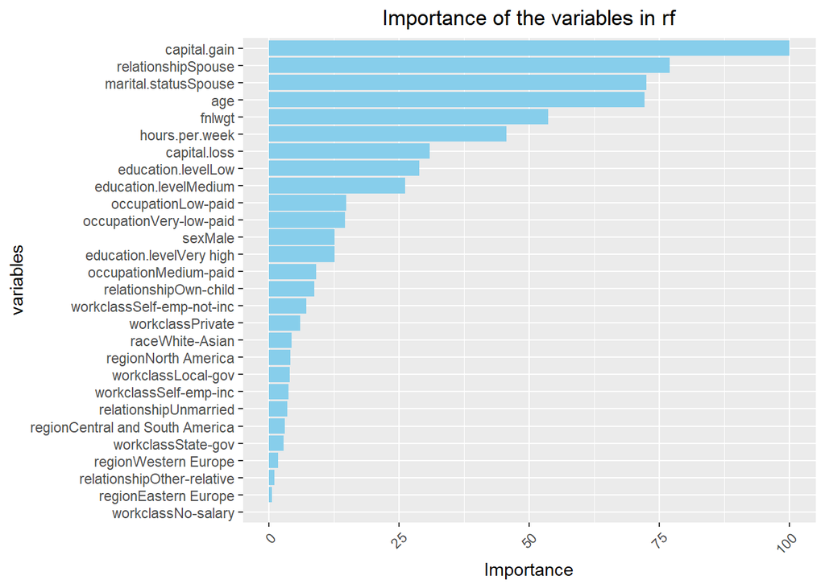

```r
#Extract the importance of the variables from the random forest
#model
importance_df <- as.data.frame(varImp(model_rf_hpo)$importance)

# Plot using ggplot2
ggplot(importance_df, aes(x = reorder(rownames(importance_df), Overall), y = Overall)) +
  geom_bar(stat = "identity", fill = "skyblue") +
  labs(x = "variables", y = "Importance", title = "Importance of the variables in rf") +
  theme(axis.text.x = element_text(angle = 45, hjust = 1)) +
  coord_flip() +
  theme(plot.title = element_text(hjust = 0.5))
```

According to this plot, the five most important variables or features in descending order are: “capital.gain”, “relationshipSpouse”,“marital.statusSpouse”,“age” and “fnlwgt” (Note that some of them are categories and not variables). For better understanding of these relationship between the values of these variables and the output we do partial dependent plots using `pdp` library. In this plots it is shown the dependence of the probability of earning more than 50.000$\$$ a year with a feature while keeping the rest constant. It is important to know that as the variables are scaled, their values are not very meaningful.

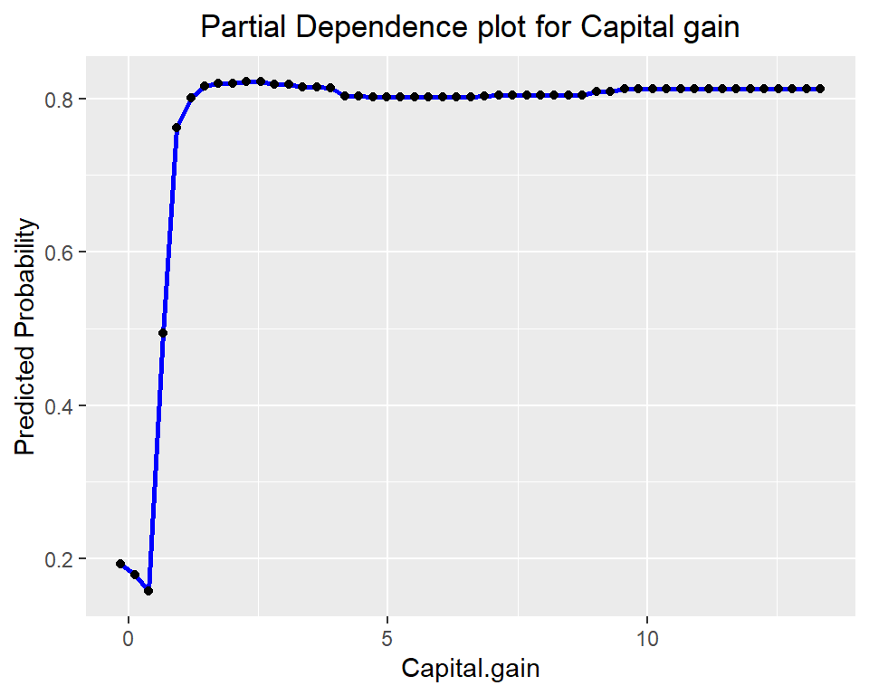

```r
pdp <- partial(model_rf_hpo, pred.var = "capital.gain", which.class = 2, plot = FALSE, prob = TRUE, rug = TRUE)

#Convert the results into a dataframe
pdp_df <- data.frame(x = pdp$capital.gain, y = pdp$yhat)

#plot the results
ggplot(pdp_df, aes(x = x, y = y)) +
  geom_line(color = "blue", size = 1) +
  geom_point(color = "black") + #In black we represent the real points
  labs(x = "Capital.gain", y = "Predicted Probability",
       title = "Partial Dependence plot for Capital gain") +
       theme(plot.title = element_text(hjust = 0.5))
```

As capital gain increases, the probability of being classified as positive abruptly rises to 0.8 and then remains relatively constant. In other words, individuals with capital gains above a certain threshold are highly likely to be classified as positive.

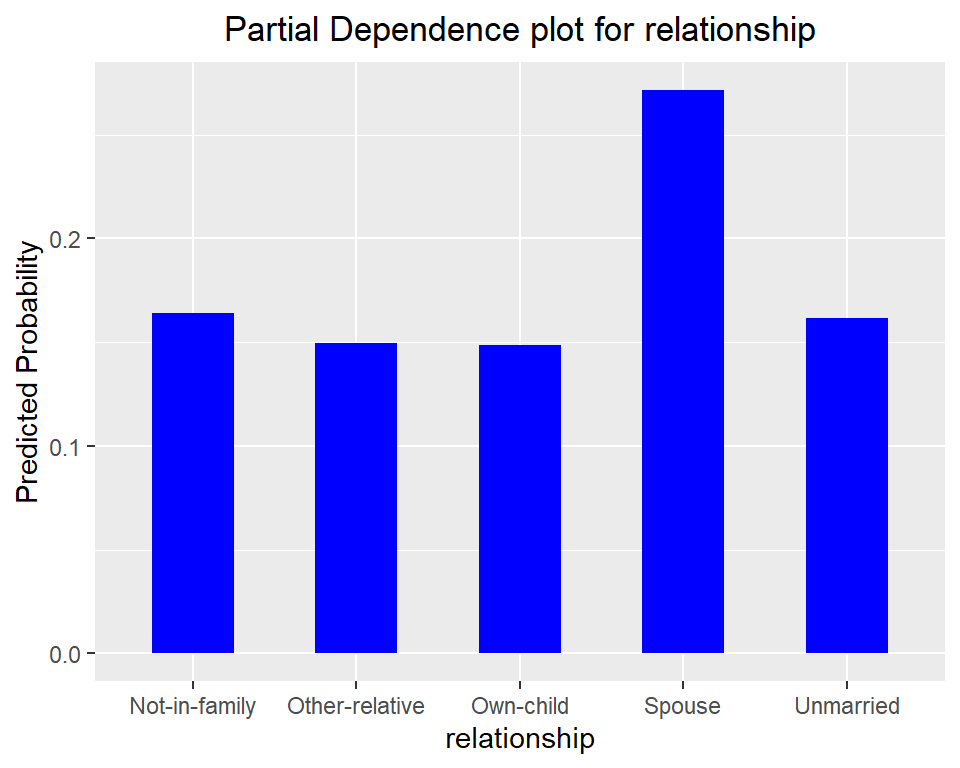

```r
pdp <- partial(model_rf_hpo, pred.var = "relationship", which.class = 2, plot = FALSE, prob = TRUE, rug = TRUE)

#Convert the results into a dataframe
pdp_df <- data.frame(x = pdp$relationship, y = pdp$yhat)

#plot the results
ggplot(pdp_df, aes(x = x, y = y)) +
  geom_bar(stat = "identity", fill = "blue", width = 0.5) +
  labs(x = "relationship", y = "Predicted Probability",
       title = "Partial Dependence plot for relationship") +
  theme(plot.title = element_text(hjust = 0.5))
```

In this plot, it can be seen that individuals with a spouse are twice as likely to be classified as positive compared to individuals with other kinds of relationships.

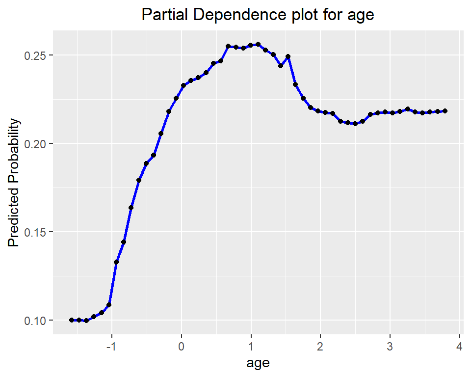

```r
pdp <- partial(model_rf_hpo, pred.var = "age", which.class = 2, plot = FALSE, prob = TRUE, rug = TRUE)

#Convert the results into a dataframe
pdp_df <- data.frame(x = pdp$age, y = pdp$yhat)

#plot the results
ggplot(pdp_df, aes(x = x, y = y)) +
  geom_line(color = "blue", size = 1) +
  geom_point(color = "black") + #In black we represent the real points
  labs(x = "age", y = "Predicted Probability",
       title = "Partial Dependence plot for age") +
       theme(plot.title = element_text(hjust = 0.5))
```

The relationship with age is more complex. The probability of being positive is very low for young people. This probability increases for older individuals until it reaches a peak of approximately 0.25. After reaching the peak, the probability begins to decrease and then stabilizes.

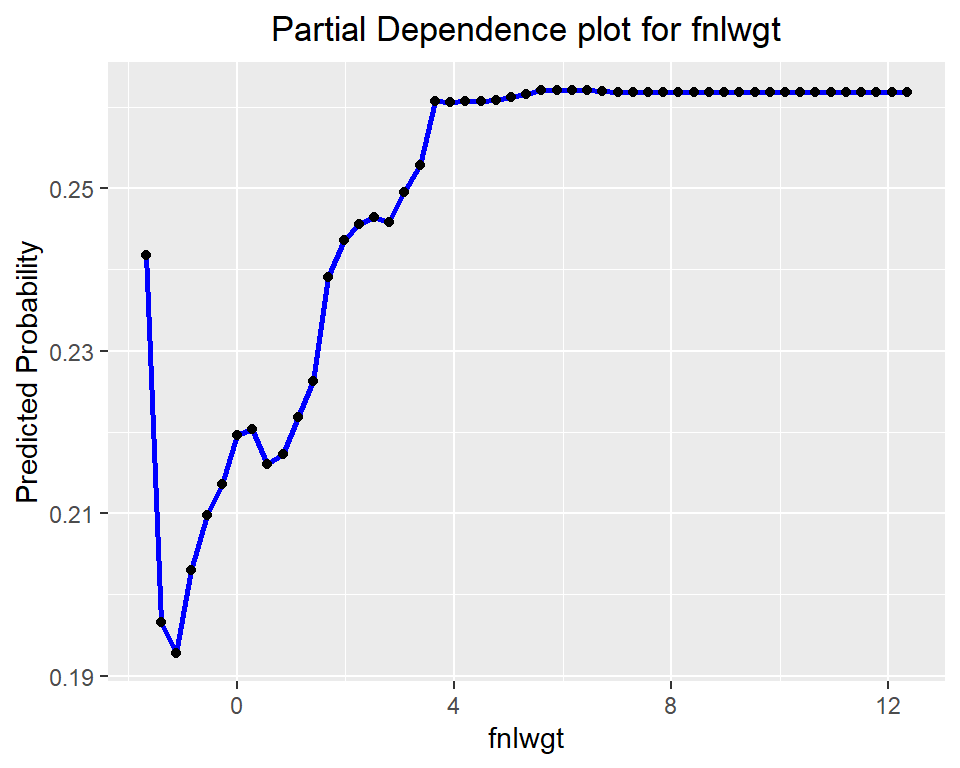

```r
pdp <- partial(model_rf_hpo, pred.var = "fnlwgt", which.class = 2, plot = FALSE, prob = TRUE, rug = TRUE)

#Convert the results into a dataframe
pdp_df <- data.frame(x = pdp$fnlwgt, y = pdp$yhat)

#plot the results
ggplot(pdp_df, aes(x = x, y = y)) +
  geom_line(color = "blue", size = 1) +
  geom_point(color = "black") + #In black we represent the real points
  labs(x = "fnlwgt", y = "Predicted Probability",
       title = "Partial Dependence plot for fnlwgt") +
       theme(plot.title = element_text(hjust = 0.5))
```

The probability of being classified as positive increases with the values of “fnlwgt” until it reaches a constant value close to $p=0.25$.

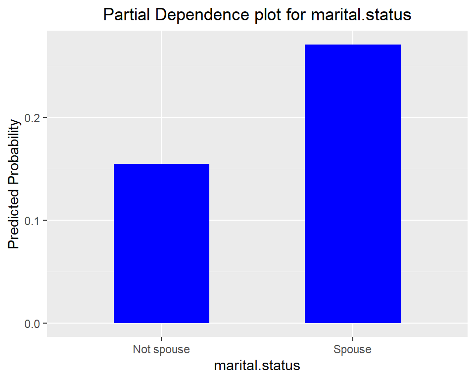

```r
pdp <- partial(model_rf_hpo, pred.var = "marital.status", which.class = 2, plot = FALSE, prob = TRUE, rug = TRUE)

#Convert the results into a dataframe
pdp_df <- data.frame(x = pdp$marital.status, y = pdp$yhat)

# plot the results as a barplot
ggplot(pdp_df, aes(x = x, y = y)) +
  geom_bar(stat = "identity", fill = "blue", width = 0.5) +
  labs(x = "marital.status", y = "Predicted Probability",
       title = "Partial Dependence plot for marital.status") +
  theme(plot.title = element_text(hjust = 0.5))
```

As with the partial plot of the variable “relationship”, it can be seen that individuals with spouse are almost twice as likely to been classified as positive with respect to people who are not married.

#### Xgboost

XGBoost (Extreme Gradient Boosting) is an ensemble learning algorithm that combines multiple weak learners, typically decision trees, to create a powerful predictive model. It sequentially builds trees, with each subsequent tree correcting the errors made by the previous ones. Unlike Random Forest, which builds trees independently, XGBoost optimizes the overall performance by penalizing complexity, thereby reducing overfitting and improving predictive accuracy. XGBoost, on the contrary to random forest, has many hyperparameters and it is necessary to tune them in order to avoid overfitting. Since training an XGBoost model is computationally expensive, we directly search for optimal hyperparameters. Due to time constraints, we will focus our grid search on parameters such as ntrees, max_depth, and eta, which controls the learning rate in the boosting process.

```r
# Define the training control
ctrl <- trainControl(method = "cv",
                     number = 5, classProbs = TRUE)

# Define the grid of hyperparameters to search
# Here we'll search over a range of values for nrounds
grid <- expand.grid(nrounds = c(10,50,100,200,500,1000),
                    max_depth = c(3,5,7,9),
                    eta = c(0.01,0.1,0.3),
                    gamma = 0,
                    colsample_bytree = 1,
                    min_child_weight = 1,
                    subsample = 1)

# Train the model with hyperparameter tuning
xgb_model <- train(income ~ .,
                   data = train,
                   method = "xgbTree",
                   trControl = ctrl,
                   tuneGrid = grid,
                   verbosity = 0)

predictions_xgb <- predict(xgb_model,newdata = test_imputed)
conf_matrix <- confusionMatrix(data = predictions_xgb, reference = test_imputed$income)
```

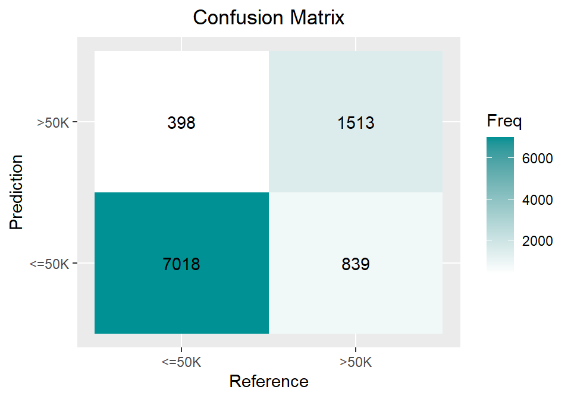

```r
#plot the confusion matrix and several quantities
conf_matrix_table <- as.data.frame(conf_matrix$table)


ggplot(conf_matrix_table, aes(x = Reference, y = Prediction,fill= Freq)) +
        geom_tile() + geom_text(aes(label=Freq)) +
        scale_fill_gradient(low="white", high="#009194") +
        labs(x = "Reference",y = "Prediction") +
        scale_x_discrete(labels=c("<=50K",">50K")) +
        scale_y_discrete(labels=c("<=50K", ">50K")) +
        ggtitle("Confusion Matrix") +
        theme(plot.title = element_text(hjust = 0.5))
```

```r
#dataframe with some metrics
metrics_df <- data.frame(
  Value = c(conf_matrix$byClass["Sensitivity"],
            conf_matrix$byClass["Specificity"],
            conf_matrix$overall["Kappa"],
            conf_matrix$overall["Accuracy"])
)

#optimal hyperparameters
xgb_model$bestTune
```

```
##    nrounds max_depth eta gamma colsample_bytree min_child_weight subsample
## 34     200         5 0.1     0                1                1         1
```

```r
#show the dataframe
print(metrics_df)
```

```
##                 Value
## Sensitivity 0.9463323
## Specificity 0.6432823
## Kappa       0.6299415
## Accuracy    0.8733620
```

The optimal hyperparameters are $ntrees = 200$, $eta = 0.1$ and $max_{depth} = 5$. It can be seen that, unlike in random forest, the performance of the model does not necessarily improve adding more number of trees.